# LeBron James vs Michael Jordan: Who is the G.O.A.T ?

Alvaro Polo García y Nicolas García Valdeande

3/12/2021

[figure not shown]

From the dawn of time, NBA fans have asked themselves on question, who is the Greatest (Basketball Player) of all Time? Decades of discussion have led nowhere, as there still isn’t a consensus on who the GOAT is.

This report will try and end the debate and statistically calculate who is the greatest basketball player of all time. In essence, we will reduce all the statistics into one number…

# Exploratory Data Analysis

```r
library(tidyverse)

nba = read.csv("./Data/NBA Season Data.csv")
```

Firstly, we must conduct a preliminary analysis on the data set. As the dataset is of great extent, we mut choose what variables will be included in the analysis. We have looked at all the variables, and with our basketball knowledge, have decided that these are the most relevant variables. The rest of the variable will not be included in the preliminary analysis or model. With the little processing power we have at our disposal, it wasn’t viable to include all 109 variables.

```r
nba = nba %>%
  select(Player.ID, Player, Year, Age, G, MP, PER, TS., TRB., AST., STL., X3PAr, BLK., TOV., VORP, Shot., Height, Rounded.Position, Weight, Yrs.Experience, WS)

head(nba)
```

```
##   Player.ID         Player Year Age  G   MP  PER   TS. TRB. AST. STL. X3PAr
## 1 robintr01 Truck Robinson 1978  26 82 3638 15.7 0.481 17.0  6.8  0.9    NA
## 2 smithra01    Randy Smith 1978  29 82 3314 19.1 0.521  5.0 22.2  2.4    NA
## 3 hayesel01    Elvin Hayes 1978  32 81 3246 17.1 0.489 16.4  6.5  1.3    NA
## 4 cowenda01    Dave Cowens 1978  29 77 3215 18.6 0.533 17.0 15.7  1.4    NA
## 5 mcadobo01     Bob McAdoo 1978  26 79 3182 22.0 0.567 16.4 13.4  1.4    NA
## 6  kingbe01   Bernard King 1978  21 79 3092 17.3 0.511 11.8  9.9  1.7    NA
##   BLK. TOV. VORP Shot. Height Rounded.Position Weight Yrs.Experience   WS
## 1  1.1 13.5  0.7  20.2     79                4    225              3  6.5
## 2  0.2 12.8  3.0  23.4     75                1    180              6  7.9
## 3  2.4 12.3  2.7  18.9     81                4    235              9  8.3
## 4  1.1 13.9  4.8  16.2     81                4    230              7 10.8
## 5  2.0 15.8  4.1  22.0     81                4    210              5 10.9
## 6  0.6 14.3  2.3  22.3     79                3    205              0  5.9
```

```r
str(nba)
```

```
## 'data.frame':    17729 obs. of  21 variables:
##  $ Player.ID       : chr  "robintr01" "smithra01" "hayesel01" "cowenda01" ...
##  $ Player          : chr  "Truck Robinson" "Randy Smith" "Elvin Hayes" "Dave Cowens" ...
##  $ Year            : int  1978 1978 1978 1978 1978 1978 1978 1978 1978 1978 ...
##  $ Age             : int  26 29 32 29 26 21 28 23 33 25 ...
##  $ G               : int  82 82 81 77 79 79 82 80 82 79 ...
##  $ MP              : int  3638 3314 3246 3215 3182 3092 3067 3025 3024 3019 ...
##  $ PER             : num  15.7 19.1 17.1 18.6 22 17.3 23.5 23.2 20.9 15.4 ...
##  $ TS.             : num  0.481 0.521 0.489 0.533 0.567 0.511 0.604 0.578 0.509 0.514 ...
##  $ TRB.            : num  17 5 16.4 17 16.4 11.8 19 6.6 7.5 5.3 ...
##  $ AST.            : num  6.8 22.2 6.5 15.7 13.4 9.9 14 19.3 22.6 27.7 ...
##  $ STL.            : num  0.9 2.4 1.3 1.4 1.4 1.7 0.6 1.3 2.4 2.5 ...
##  $ X3PAr           : num  NA NA NA NA NA NA NA NA NA NA ...
##  $ BLK.            : num  1.1 0.2 2.4 1.1 2 0.6 3.2 1.7 0.8 0.4 ...
##  $ TOV.            : num  13.5 12.8 12.3 13.9 15.8 14.3 19.1 11.5 10.7 20.1 ...
##  $ VORP            : num  0.7 3 2.7 4.8 4.1 2.3 4.8 4 3.7 1.8 ...
##  $ Shot.           : num  20.2 23.4 18.9 16.2 22 22.3 20.5 23.7 24.2 17.4 ...
##  $ Height          : chr  "79" "75" "81" "81" ...
##  $ Rounded.Position: chr  "4" "1" "4" "4" ...
##  $ Weight          : chr  "225" "180" "235" "230" ...
##  $ Yrs.Experience  : chr  "3" "6" "9" "7" ...
##  $ WS              : num  6.5 7.9 8.3 10.8 10.9 5.9 11.5 12.7 9.7 4.8 ...
```

We transform the variables from type “char” to a “factor” and from “int to”numeric".

```r
nba$Weight = as.numeric(nba$Weight)
nba$Height = as.numeric(nba$Height)
nba$Yrs.Experience = as.numeric(nba$Yrs.Experience)
nba$Year= as.numeric(nba$Year)
nba$Age = as.numeric(nba$Age)
nba$MP = as.numeric(nba$MP)
nba$G = as.numeric(nba$G)

nba$Rounded.Position = as.factor(nba$Rounded.Position)
nba$Player.ID = as.factor(nba$Player.ID)
nba$Player = as.factor(nba$Player)


str(nba)
```

```
## 'data.frame':    17729 obs. of  21 variables:
##  $ Player.ID       : Factor w/ 2804 levels "","#NAME?","abdelal01",..: 2112 2305 1069 526 1615 1389 895 2451 151 2322 ...
##  $ Player          : Factor w/ 2828 levels "0","A.C. Green",..: 2695 2167 874 633 252 205 170 658 2228 2249 ...
##  $ Year            : num  1978 1978 1978 1978 1978 ...
##  $ Age             : num  26 29 32 29 26 21 28 23 33 25 ...
##  $ G               : num  82 82 81 77 79 79 82 80 82 79 ...
##  $ MP              : num  3638 3314 3246 3215 3182 ...
##  $ PER             : num  15.7 19.1 17.1 18.6 22 17.3 23.5 23.2 20.9 15.4 ...
##  $ TS.             : num  0.481 0.521 0.489 0.533 0.567 0.511 0.604 0.578 0.509 0.514 ...
##  $ TRB.            : num  17 5 16.4 17 16.4 11.8 19 6.6 7.5 5.3 ...
##  $ AST.            : num  6.8 22.2 6.5 15.7 13.4 9.9 14 19.3 22.6 27.7 ...
##  $ STL.            : num  0.9 2.4 1.3 1.4 1.4 1.7 0.6 1.3 2.4 2.5 ...
##  $ X3PAr           : num  NA NA NA NA NA NA NA NA NA NA ...
##  $ BLK.            : num  1.1 0.2 2.4 1.1 2 0.6 3.2 1.7 0.8 0.4 ...
##  $ TOV.            : num  13.5 12.8 12.3 13.9 15.8 14.3 19.1 11.5 10.7 20.1 ...
##  $ VORP            : num  0.7 3 2.7 4.8 4.1 2.3 4.8 4 3.7 1.8 ...
##  $ Shot.           : num  20.2 23.4 18.9 16.2 22 22.3 20.5 23.7 24.2 17.4 ...
##  $ Height          : num  79 75 81 81 81 79 86 76 79 75 ...
##  $ Rounded.Position: Factor w/ 7 levels "#N/A","0","1",..: 6 3 6 6 6 5 7 4 4 3 ...
##  $ Weight          : num  225 180 235 230 210 205 240 195 205 198 ...
##  $ Yrs.Experience  : num  3 6 9 7 5 0 6 2 11 2 ...
##  $ WS              : num  6.5 7.9 8.3 10.8 10.9 5.9 11.5 12.7 9.7 4.8 ...
```

Next, we check the dimensions of the data set.

```r
dim(nba)
```

```
## [1] 17729    21
```

We then check to see how many NA values we have in the data set. If there are any, we are going to have to either transform them or delete them.

```r
apply(is.na(nba),2,sum)
```

```
##        Player.ID           Player             Year              Age
##                0                0                0                0
##                G               MP              PER              TS.
##                0                0                0               66
##             TRB.             AST.             STL.            X3PAr
##                0                0                0              718
##             BLK.             TOV.             VORP            Shot.
##                0               51                0                0
##           Height Rounded.Position           Weight   Yrs.Experience
##              468                0              468              468
##               WS
##                0
```

We can observe that there are some NA values, but we can explain most of these. Given that the data set was posted during the 2016 season, most of the data from 2016 is incomplete (NA). Therefore, we will have to do something about this, as we can’t have NA values in our model. In addition, there are 718 missing values for 3 point attempts. This is due to the 3 point line to being introduced until 1979, therefore we have some years where that statistic could not be calculated.

Most of the NA values are from the 2016 season, so we our model will not take into account 2016 (Unfortunate as LeBron had an all-time great year, winning the Finals with the Cavs).

```r
nba = nba %>%
  filter(Year != "2016")

tail(nba)
```

```
##       Player.ID           Player Year Age G MP   PER TS. TRB. AST. STL. X3PAr
## 16854 lucaska01      Kalin Lucas 2015  25 1  6  -0.7 0.0  0.0  0.0  8.7     0
## 16855 benimje01 Jerrelle Benimon 2015  23 2  3   4.7 0.0 57.8  0.0  0.0     0
## 16856 bhullsi01      Sim Bhullar 2015  22 3  3  44.3 0.5 18.9 78.5  0.0     0
## 16857 moreler01    Eric Moreland 2015  23 3  2  40.8 1.0 28.4  0.0  0.0     0
## 16858   leema01      Malcolm Lee 2015  24 1  2 -19.7 0.0  0.0  0.0  0.0     0
## 16859 murryto01     Toure' Murry 2015  25 1  1 -41.7 0.0  0.0  0.0  0.0     0
##       BLK. TOV. VORP Shot. Height Rounded.Position Weight Yrs.Experience WS
## 16854  0.0    0    0   7.6     73                1    195              0  0
## 16855  0.0  100    0   0.0     80                5    245              0  0
## 16856 26.3    0    0  29.4     89                5    360              0  0
## 16857  0.0    0    0  22.0     82                5    238              0  0
## 16858  0.0    0    0  21.8     77                2    200              2  0
## 16859  0.0    0    0  45.8     77                2    195              1  0
```

```r
nba = na.omit(nba)
```

We check again if there are any NA values, after deleting the 2016 season stats.

```r
any(is.na(nba))
```

```
## [1] FALSE
```

```r
nba = nba %>%
  filter(MP > 400)
```

We also want a Minutes Per Game (MPG) variable, as it is easier to work with, when compared to Total Minutes Played (MP) and Games Played (G).

```r
nba = nba %>%
  mutate(MPG = MP/G) %>%
  select(-MP, -G)

head(nba)
```

```
##   Player.ID              Player Year Age  PER   TS. TRB. AST. STL. X3PAr BLK.
## 1 nixonno01          Norm Nixon 1980  24 14.9 0.548  3.9 25.3  2.1 0.007  0.2
## 2 hayesel01         Elvin Hayes 1980  34 17.2 0.492 14.1  6.1  0.9 0.008  3.1
## 3 cartwbi01     Bill Cartwright 1980  22 17.9 0.608 12.6  7.0  0.7 0.000  1.7
## 4 abdulka01 Kareem Abdul-Jabbar 1980  32 25.3 0.639 15.4 16.5  1.2 0.001  4.6
## 5 malonmo01        Moses Malone 1980  24 24.1 0.560 20.9  7.1  1.2 0.004  1.9
## 6 wilkeja01       Jamaal Wilkes 1980  26 17.6 0.563  9.2 10.8  1.9 0.013  0.5
##   TOV. VORP Shot. Height Rounded.Position Weight Yrs.Experience   WS      MPG
## 1 17.9  1.0  16.4     74                1    170              2  6.7 39.34146
## 2 10.2  1.2  23.4     81                4    235             11  6.2 39.29630
## 3 13.2  1.9  17.9     85                5    245              0  9.7 38.41463
## 4 15.7  6.3  20.3     86                5    225             10 14.8 38.32927
## 5 13.7  3.8  23.8     82                4    215              5 11.9 38.29268
## 6  9.7  3.0  18.8     78                2    190              5 10.0 37.93902
```

We are now going to start to build our multivariate linear regression model.

Firstly, we must decide the output variable. It is common to use the Points per Game (PPG) variable when deciding who the best player is (similar thing happens with football, fans compare the amount of goals scored), but basketball is much more than just scoring points. If we selected PPG, then we would not take into account defence, rebounding and, playmaking, all key attributes to become the GOAT. So, instead of using PPG, we have to chosen the Win Share (WS). WS is a player statistic which attempts to divvy up credit for team success to the individuals on the team, measuring the impact the player has on the number of wins. The higher the WS variable is, the more a player contributes to the teams win.

Now we are going explore the relationship between WS and the other variables we have selected. If they have some sort of relationship, they could be included in the final model.

**Relation between MPG (Minutes Per Game) and WS**

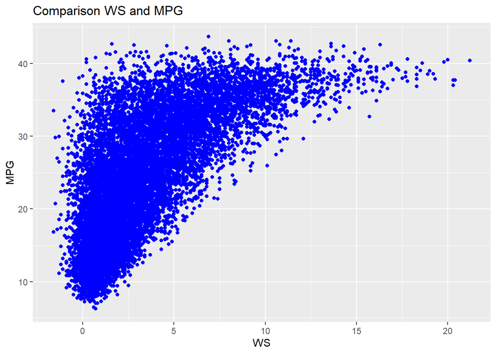

```r
ggplot(data = nba) +
  geom_point(mapping = aes(x = WS, y = MPG), col = "blue")+
  ggtitle("Comparison WS and MPG ")
```

**Relation between PER (Player efficiency rate) and WS**

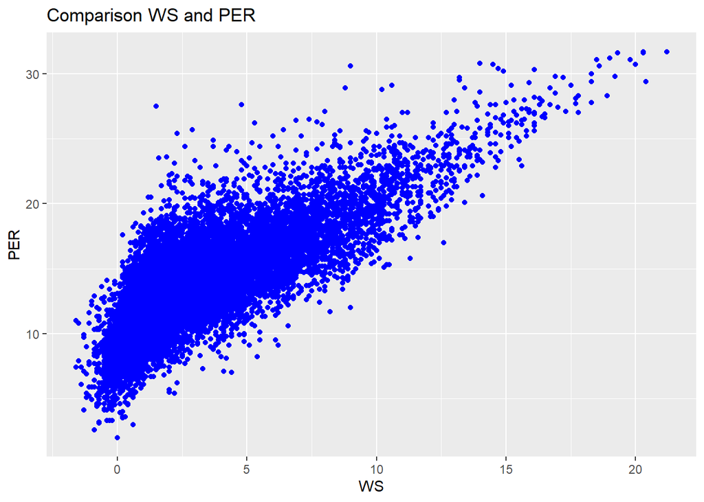

```r
ggplot(data = nba) +
  geom_point(mapping = aes(x = WS, y = PER), col = "blue")+
  ggtitle("Comparison WS and PER ")
```

**Relation between TS.(True shooting) and WS**

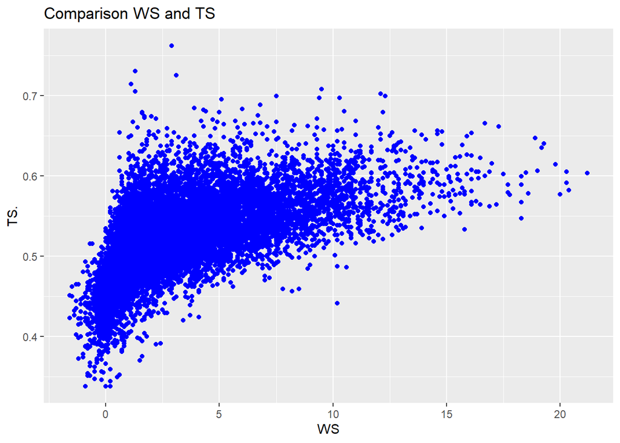

```r
ggplot(data = nba) +
  geom_point(mapping = aes(x = WS, y = TS.), col = "blue")+
  ggtitle("Comparison WS and TS ")
```

**Relation between TRB.(Total Rebounds) and WS**

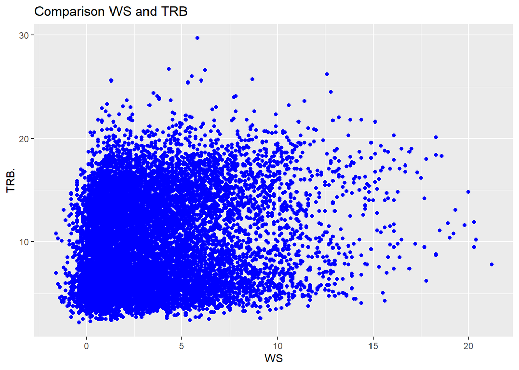

```r
ggplot(data = nba) +
  geom_point(mapping = aes(x = WS, y = TRB.), col = "blue")+
  ggtitle("Comparison WS and TRB")
```

**Relation between AST.(Assists) and WS**

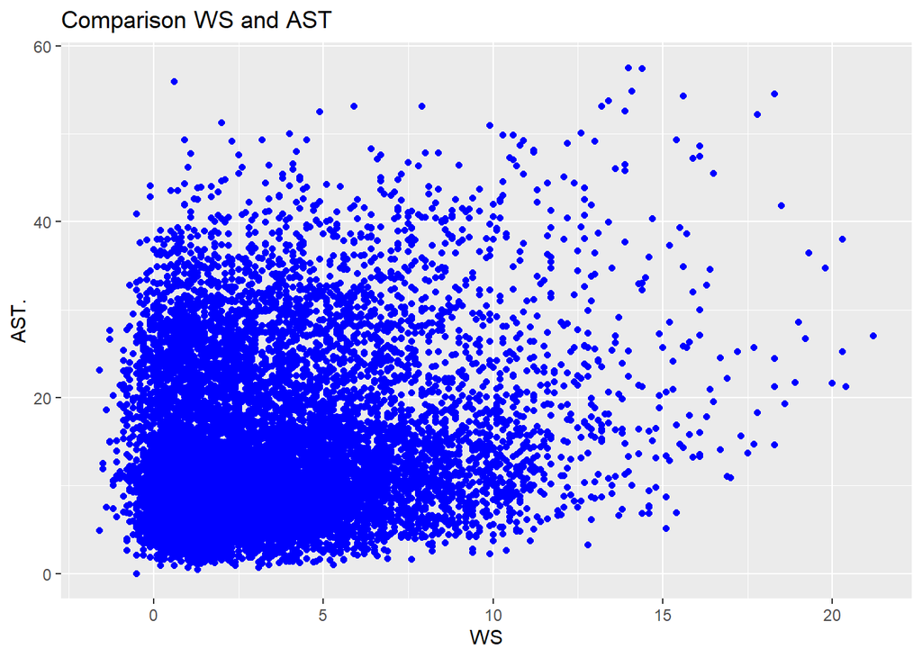

```r
ggplot(data = nba) +
  geom_point(mapping = aes(x = WS, y = AST.), col = "blue")+
  ggtitle("Comparison WS and AST ")
```

**Relation between STL.(Steal%) and WS**

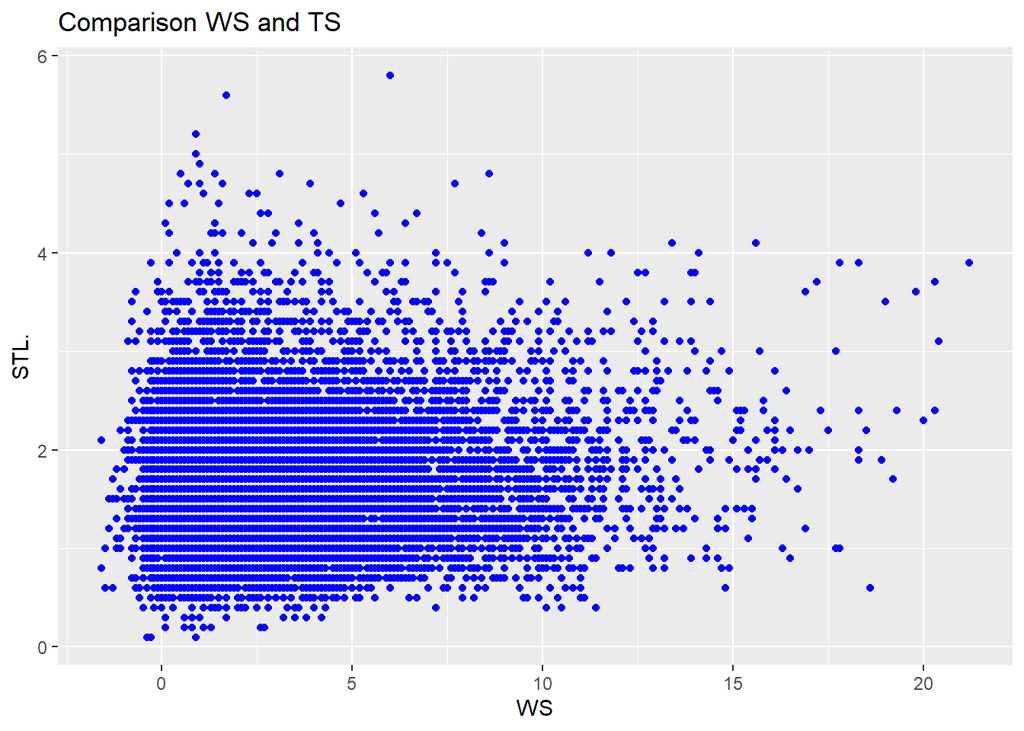

```r
ggplot(data = nba) +
  geom_point(mapping = aes(x = WS, y = STL.), col = "blue")+
  ggtitle("Comparison WS and TS ")
```

**Relation between X3PAR(X3 attemps %) and WS**

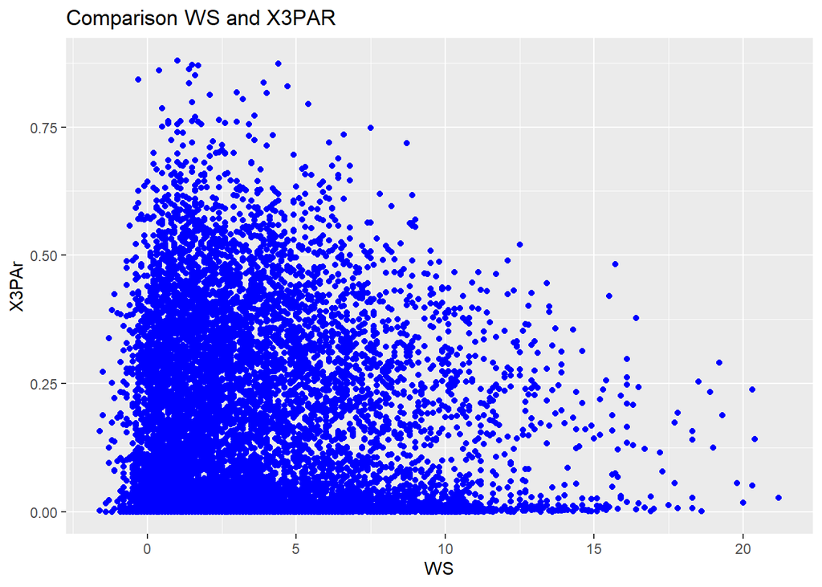

```r
ggplot(data = nba) +
  geom_point(mapping = aes(x = WS, y = X3PAr), col = "blue")+
  ggtitle("Comparison WS and X3PAR ")
```

**Relation between BLK(BLOCKS %) and WS**

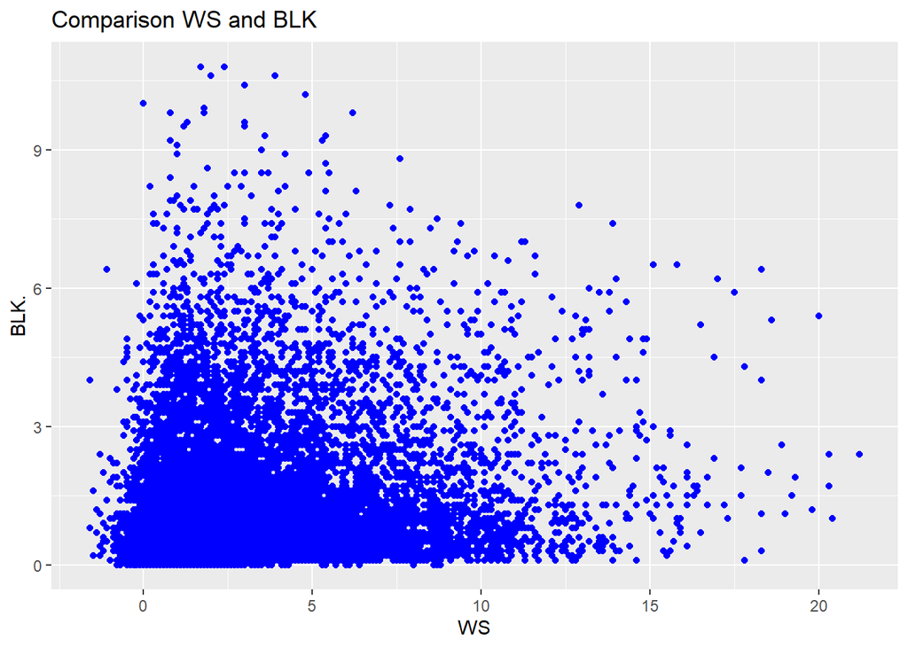

```r
ggplot(data = nba) +
  geom_point(mapping = aes(x = WS, y = BLK.), col = "blue")+
  ggtitle("Comparison WS and BLK")
```

**Relation between TOV.(Balls lost %) and WS**

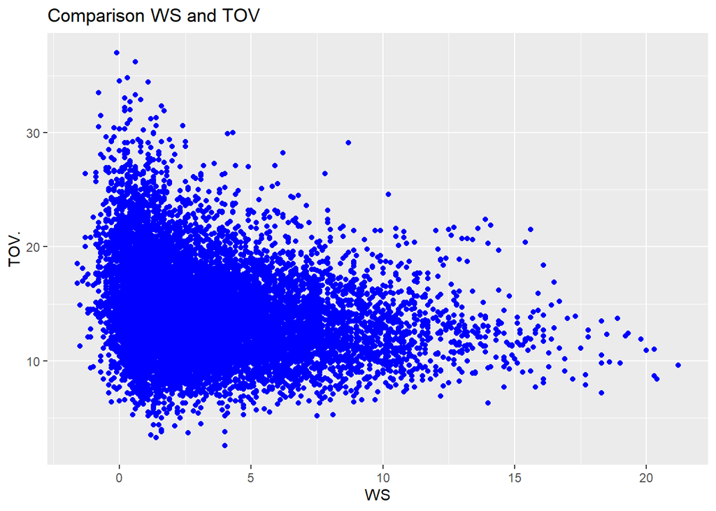

```r
ggplot(data = nba) +
  geom_point(mapping = aes(x = WS, y = TOV.), col = "blue")+
  ggtitle("Comparison WS and TOV ")
```

**Relation between VORP.(Value over replacement player) and WS**

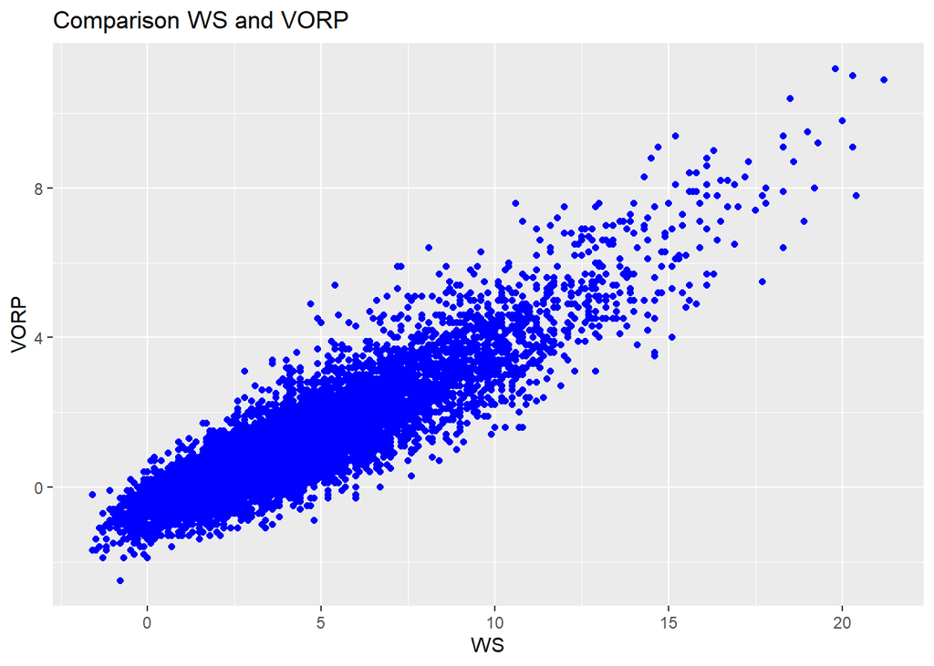

```r
ggplot(data = nba) +
  geom_point(mapping = aes(x = WS, y = VORP), col = "blue")+
  ggtitle("Comparison WS and VORP ")
```

After looking at all these relationships, we are going to calculate the correlation WS has with the other variables in order to find out which ones show a strong relationship.

**Correlagram**

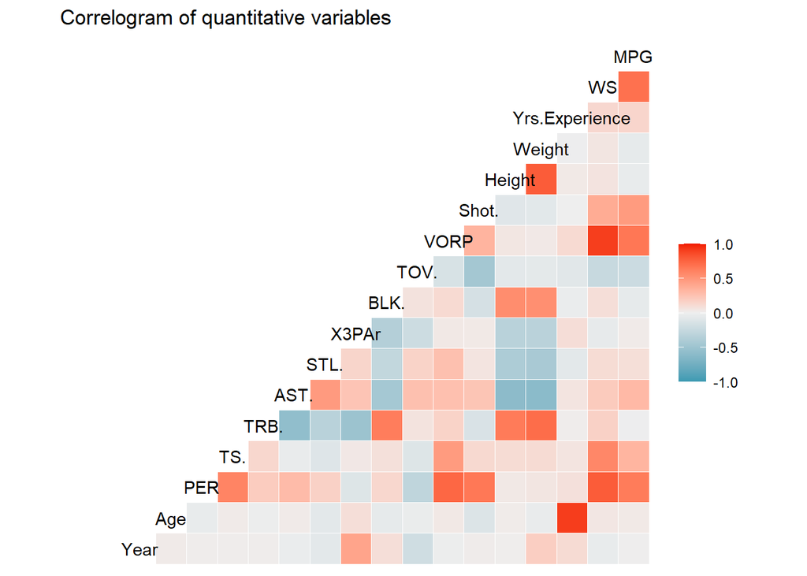

```r
library(GGally)

ggcorr(nba, layout.exp = 2) + labs(title='Correlogram of quantitative variables')
```

We observe that the variables that VORP, TS and PER have a strong correlation with WS.

Taking into account the correlogram of quantitative variables, we can also obtain the numerical correlation matrix.

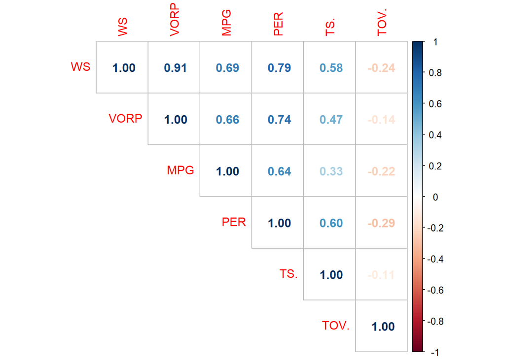

```r
library(corrplot)

nba_gg <- nba%>%
  select(WS, VORP, MPG, PER, TS., TOV.)

correlacion<-cor(nba_gg)

corrplot(correlacion, method = "number", type = "upper")
```

As hypothesized before, we observe that the correlation between WS and VORP is very strong (0.91). The correlation between WS and TS is not as strong as previously thought.

We going to add the age variable into 3 categories. Young (ages between 18 and 24), Prime (ages between 25 and 32) and Experienced (ages from 33 on wards).

```r
v1 = nba$Age

v1_cut = cut(v1, breaks = c(min(v1), 24, 32, max(v1)), labels = c("YOUNG", "PRIME", "EXPERIENCED"))
v1_cut[1:5]
```

```
## [1] YOUNG       EXPERIENCED YOUNG       PRIME       YOUNG
## Levels: YOUNG PRIME EXPERIENCED
```

```r
nba = nba %>%
  mutate(age_Cat = v1_cut)

head(nba)
```

```
##   Player.ID              Player Year Age  PER   TS. TRB. AST. STL. X3PAr BLK.
## 1 nixonno01          Norm Nixon 1980  24 14.9 0.548  3.9 25.3  2.1 0.007  0.2
## 2 hayesel01         Elvin Hayes 1980  34 17.2 0.492 14.1  6.1  0.9 0.008  3.1
## 3 cartwbi01     Bill Cartwright 1980  22 17.9 0.608 12.6  7.0  0.7 0.000  1.7
## 4 abdulka01 Kareem Abdul-Jabbar 1980  32 25.3 0.639 15.4 16.5  1.2 0.001  4.6
## 5 malonmo01        Moses Malone 1980  24 24.1 0.560 20.9  7.1  1.2 0.004  1.9
## 6 wilkeja01       Jamaal Wilkes 1980  26 17.6 0.563  9.2 10.8  1.9 0.013  0.5
##   TOV. VORP Shot. Height Rounded.Position Weight Yrs.Experience   WS      MPG
## 1 17.9  1.0  16.4     74                1    170              2  6.7 39.34146
## 2 10.2  1.2  23.4     81                4    235             11  6.2 39.29630
## 3 13.2  1.9  17.9     85                5    245              0  9.7 38.41463
## 4 15.7  6.3  20.3     86                5    225             10 14.8 38.32927
## 5 13.7  3.8  23.8     82                4    215              5 11.9 38.29268
## 6  9.7  3.0  18.8     78                2    190              5 10.0 37.93902
##       age_Cat
## 1       YOUNG
## 2 EXPERIENCED
## 3       YOUNG
## 4       PRIME
## 5       YOUNG
## 6       PRIME
```

Graphical analysis between the correlation of Ws/AGe and WS/POs.

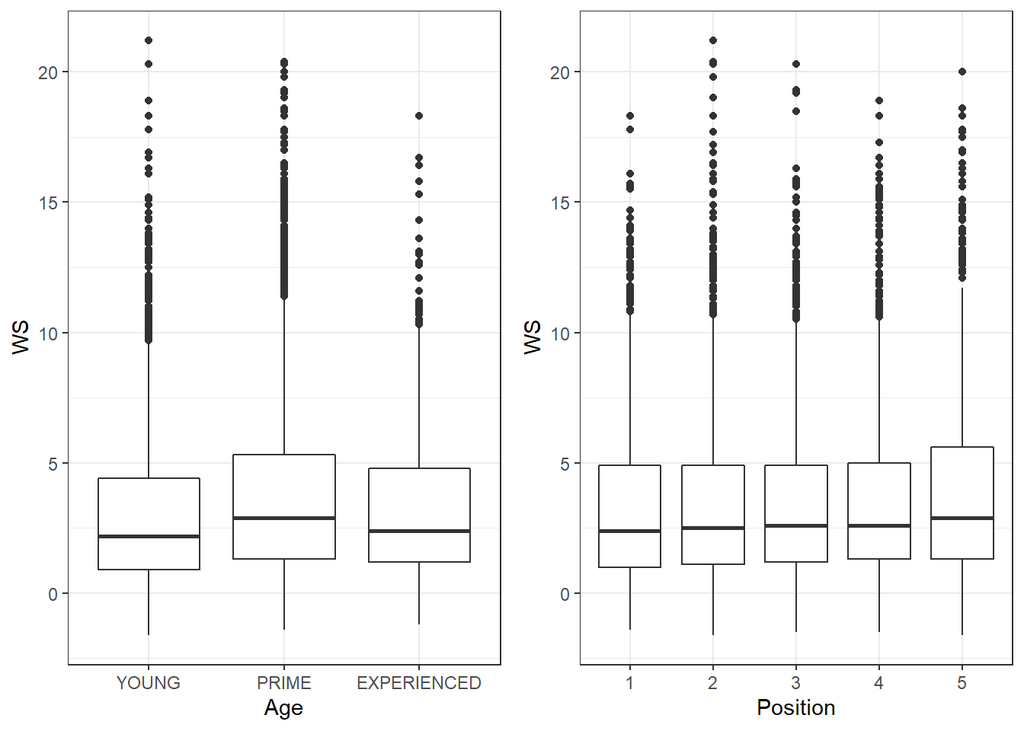

```r
nba = na.omit(nba)

library(ggpubr)

p1 <- ggplot(data = nba) +
      geom_boxplot(mapping = aes(x = age_Cat, y = WS))+
      labs(x = "Age")+
      theme_bw()

p2 <- ggplot(data = nba) +
      geom_boxplot(mapping = aes(x = Rounded.Position, y = WS))+
      labs(x = "Position")+
      theme_bw()

final_plot <- ggarrange(p1, p2)

final_plot
```

We can clearly see how the position does not have a correlation with Ws. On the other hand we can see how players in their prime do influence thw WS more, than the other 2 age categories

# Model Building

Predicting the WS with all the other variables. This report will focus the analysis on two main players, LeBron James and Michael Jordan. Although there is no consensus regarding who is the GOAT, there is more consensus that the debate is mainly between these 2 players.

Therefore, we exclude their observations from the model, as we do not to influence the model.

```r
nba_model = nba %>%
  filter(Player != "Michael Jordan" & Player != "LeBron James") %>%
  select(-Player.ID, -Year, -Player, -Age, -age_Cat, -Rounded.Position)

head(nba_model)
```

```
##    PER   TS. TRB. AST. STL. X3PAr BLK. TOV. VORP Shot. Height Weight
## 1 14.9 0.548  3.9 25.3  2.1 0.007  0.2 17.9  1.0  16.4     74    170
## 2 17.2 0.492 14.1  6.1  0.9 0.008  3.1 10.2  1.2  23.4     81    235
## 3 17.9 0.608 12.6  7.0  0.7 0.000  1.7 13.2  1.9  17.9     85    245
## 4 25.3 0.639 15.4 16.5  1.2 0.001  4.6 15.7  6.3  20.3     86    225
## 5 24.1 0.560 20.9  7.1  1.2 0.004  1.9 13.7  3.8  23.8     82    215
## 6 17.6 0.563  9.2 10.8  1.9 0.013  0.5  9.7  3.0  18.8     78    190
##   Yrs.Experience   WS      MPG
## 1              2  6.7 39.34146
## 2             11  6.2 39.29630
## 3              0  9.7 38.41463
## 4             10 14.8 38.32927
## 5              5 11.9 38.29268
## 6              5 10.0 37.93902
```

## Multivariate linear regression model

Checking to see if we have any outliers. Most of the outliers we encounter will be statistical outliers, but we can’t delete them, as some players are just a lot better than the average.

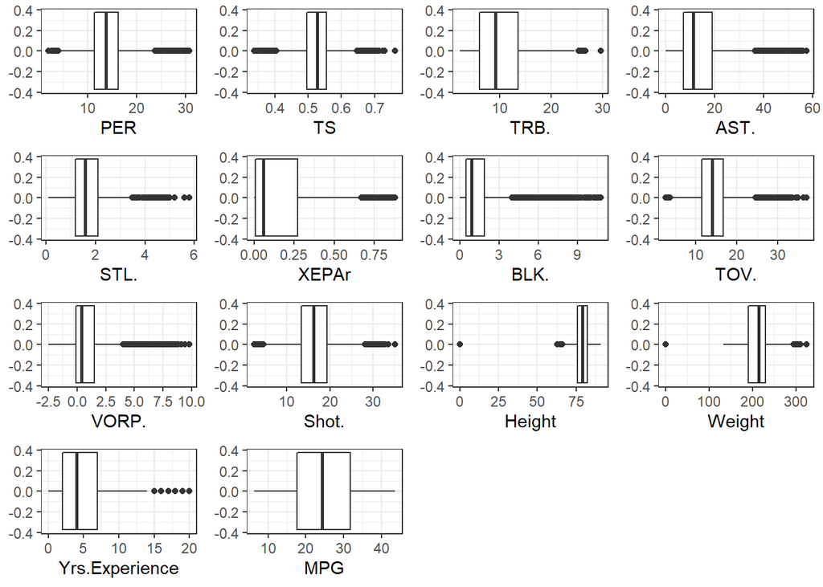

```r
library(ggpubr)

p1 <- ggplot(data = nba_model) +
      geom_boxplot(mapping = aes(x = PER)) +
      labs(x = "PER")+
      theme_bw()

p2 <- ggplot(data = nba_model) +
      geom_boxplot(mapping = aes(x = TS.))+
      labs(x = "TS")+
      theme_bw()

p3 <- ggplot(data = nba_model) +
      geom_boxplot(mapping = aes(x = TRB.))+
      labs(x = "TRB.")+
      theme_bw()

p4 <- ggplot(data = nba_model) +
      geom_boxplot(mapping = aes(x = AST.))+
      labs(x = "AST.")+
      theme_bw()

p5 <- ggplot(data = nba_model) +
      geom_boxplot(mapping = aes(x = STL.))+
      labs(x = "STL.")+
      theme_bw()

p6 <- ggplot(data = nba_model) +
      geom_boxplot(mapping = aes(x = X3PAr)) +
      labs(x = "XEPAr")+
      theme_bw()

p7 <- ggplot(data = nba_model) +
      geom_boxplot(mapping = aes(x = BLK.)) +
      labs(x = "BLK.")+
      theme_bw()

p8 <- ggplot(data = nba_model) +
      geom_boxplot(mapping = aes(x = TOV.)) +
      labs(x = "TOV.")+
      theme_bw()

p9 <- ggplot(data = nba_model) +
      geom_boxplot(mapping = aes(x = VORP)) +
      labs(x = "VORP.")+
      theme_bw()

p10 <- ggplot(data = nba_model) +
      geom_boxplot(mapping = aes(x = Shot.)) +
      labs(x = "Shot.")+
      theme_bw()

p11 <- ggplot(data = nba_model) +
      geom_boxplot(mapping = aes(x = Height)) +
      labs(x = "Height")+
      theme_bw()

p12 <- ggplot(data = nba_model) +
      geom_boxplot(mapping = aes(x = Weight)) +
      labs(x = "Weight")+
      theme_bw()

p13 <- ggplot(data = nba_model) +
      geom_boxplot(mapping = aes(x = Yrs.Experience)) +
      labs(x = "Yrs.Experience")+
      theme_bw()

p14 <- ggplot(data = nba_model) +
      geom_boxplot(mapping = aes(x = MPG)) +
      labs(x = "MPG")+
      theme_bw()


final_plot <- ggarrange(p1, p2, p3, p4, p5, p6, p7, p8, p9, p10, p11, p12, p13, p14)

final_plot
```

In the above graph, we can see how there are some players whose Height and Weight equal 0. It is physically impossible to not weigh anything or to be 0 inches tall, therefore we will ignore these values.

```r
nba_model = nba_model %>%
  filter(Weight > 0 & Height > 0)
```

```r
str(nba_model)
```

```
## 'data.frame':    11499 obs. of  15 variables:
##  $ PER           : num  14.9 17.2 17.9 25.3 24.1 17.6 17.8 17 15.4 20.6 ...
##  $ TS.           : num  0.548 0.492 0.608 0.639 0.56 0.563 0.517 0.579 0.545 0.529 ...
##  $ TRB.          : num  3.9 14.1 12.6 15.4 20.9 9.2 9.6 6.1 18.5 4.9 ...
##  $ AST.          : num  25.3 6.1 7 16.5 7.1 10.8 34.1 25.9 15.6 20.7 ...
##  $ STL.          : num  2.1 0.9 0.7 1.2 1.2 1.9 3.9 1.8 1 3.2 ...
##  $ X3PAr         : num  0.007 0.008 0 0.001 0.004 0.013 0.103 0.09 0.003 0.023 ...
##  $ BLK.          : num  0.2 3.1 1.7 4.6 1.9 0.5 0.6 0.4 1.1 0.7 ...
##  $ TOV.          : num  17.9 10.2 13.2 15.7 13.7 9.7 22.9 19.5 17.3 9.5 ...
##  $ VORP          : num  1 1.2 1.9 6.3 3.8 3 4.3 2.7 4.6 4.2 ...
##  $ Shot.         : num  16.4 23.4 17.9 20.3 23.8 18.8 15.2 19.3 9.7 22.8 ...
##  $ Height        : num  74 81 85 86 82 78 77 79 79 74 ...
##  $ Weight        : num  170 235 245 225 215 190 189 190 245 175 ...
##  $ Yrs.Experience: num  2 11 0 10 5 5 1 1 11 4 ...
##  $ WS            : num  6.7 6.2 9.7 14.8 11.9 10 6 6.9 8.4 11.6 ...
##  $ MPG           : num  39.3 39.3 38.4 38.3 38.3 ...
##  - attr(*, "na.action")= 'omit' Named int [1:3] 5038 5152 5383
##   ..- attr(*, "names")= chr [1:3] "5038" "5152" "5383"
```

We then move on to calculate the Pearson Correlation matrix, given that most of our variables have a linear relationship.

```r
round(cor(x = nba_model, method = "pearson"), 3)
```

```
##                   PER    TS.   TRB.   AST.   STL.  X3PAr   BLK.   TOV.   VORP
## PER             1.000  0.598  0.198  0.282  0.155 -0.108  0.136 -0.290  0.735
## TS.             0.598  1.000  0.134 -0.034 -0.107  0.038  0.081 -0.108  0.474
## TRB.            0.198  0.134  1.000 -0.572 -0.332 -0.507  0.632  0.066  0.160
## AST.            0.282 -0.034 -0.572  1.000  0.475  0.241 -0.454  0.270  0.256
## STL.            0.155 -0.107 -0.332  0.475  1.000  0.148 -0.273  0.161  0.255
## X3PAr          -0.108  0.038 -0.507  0.241  0.148  1.000 -0.361 -0.212  0.038
## BLK.            0.136  0.081  0.632 -0.454 -0.273 -0.361  1.000  0.069  0.121
## TOV.           -0.290 -0.108  0.066  0.270  0.161 -0.212  0.069  1.000 -0.141
## VORP            0.735  0.474  0.160  0.256  0.255  0.038  0.121 -0.141  1.000
## Shot.           0.651  0.118 -0.136  0.229  0.048  0.033 -0.161 -0.459  0.316
## Height          0.039  0.119  0.758 -0.706 -0.476 -0.382  0.649 -0.086  0.049
## Weight          0.054  0.110  0.733 -0.623 -0.443 -0.331  0.552 -0.064  0.030
## Yrs.Experience  0.077  0.055  0.013  0.055 -0.073  0.097 -0.023 -0.078  0.118
## WS              0.788  0.580  0.168  0.194  0.095 -0.041  0.093 -0.241  0.907
## MPG             0.638  0.326 -0.007  0.300  0.083  0.026 -0.050 -0.218  0.665
##                 Shot. Height Weight Yrs.Experience     WS    MPG
## PER             0.651  0.039  0.054          0.077  0.788  0.638
## TS.             0.118  0.119  0.110          0.055  0.580  0.326
## TRB.           -0.136  0.758  0.733          0.013  0.168 -0.007
## AST.            0.229 -0.706 -0.623          0.055  0.194  0.300
## STL.            0.048 -0.476 -0.443         -0.073  0.095  0.083
## X3PAr           0.033 -0.382 -0.331          0.097 -0.041  0.026
## BLK.           -0.161  0.649  0.552         -0.023  0.093 -0.050
## TOV.           -0.459 -0.086 -0.064         -0.078 -0.241 -0.218
## VORP            0.316  0.049  0.030          0.118  0.907  0.665
## Shot.           1.000 -0.097 -0.072         -0.004  0.368  0.470
## Height         -0.097  1.000  0.813          0.030  0.064 -0.047
## Weight         -0.072  0.813  1.000         -0.011  0.051 -0.050
## Yrs.Experience -0.004  0.030 -0.011          1.000  0.129  0.141
## WS              0.368  0.064  0.051          0.129  1.000  0.694
## MPG             0.470 -0.047 -0.050          0.141  0.694  1.000
```

We build our first model with all our variables.

```r
modelo <- lm(WS ~ ., data = nba_model )
summary(modelo)
```

```
##
## Call:
## lm(formula = WS ~ ., data = nba_model)
##
## Residuals:
##     Min      1Q  Median      3Q     Max
## -5.4473 -0.5941  0.0022  0.5865  5.2448
##
## Coefficients:
##                  Estimate Std. Error t value Pr(>|t|)
## (Intercept)     5.3975470  0.4317058  12.503  < 2e-16 ***
## PER             0.2870985  0.0104483  27.478  < 2e-16 ***
## TS.             0.9938995  0.4312481   2.305   0.0212 *
## TRB.           -0.0728619  0.0052031 -14.003  < 2e-16 ***
## AST.           -0.0394026  0.0026657 -14.781  < 2e-16 ***
## STL.           -0.6864420  0.0191114 -35.918  < 2e-16 ***
## X3PAr          -1.5517446  0.0670732 -23.135  < 2e-16 ***
## BLK.           -0.1813916  0.0097961 -18.517  < 2e-16 ***
## TOV.           -0.0268907  0.0038991  -6.897 5.60e-12 ***
## VORP            1.5266468  0.0116075 131.522  < 2e-16 ***
## Shot.          -0.1074462  0.0047717 -22.517  < 2e-16 ***
## Height         -0.0428694  0.0054573  -7.855 4.34e-15 ***
## Weight         -0.0005677  0.0006189  -0.917   0.3590
## Yrs.Experience  0.0038773  0.0025020   1.550   0.1212
## MPG             0.0293421  0.0016163  18.154  < 2e-16 ***
## ---
## Signif. codes:  0 '***' 0.001 '**' 0.01 '*' 0.05 '.' 0.1 ' ' 1
##
## Residual standard error: 0.9689 on 11484 degrees of freedom
## Multiple R-squared:  0.8986, Adjusted R-squared:  0.8985
## F-statistic:  7269 on 14 and 11484 DF,  p-value: < 2.2e-16
```

There are several variables that are not statistically significant, those with a p-value larger than 0.05. We use the stepwise variable selection method to include only statistically significant variables.

```r
step(object = modelo, direction = "both", trace = 1)
```

```
## Start:  AIC=-710.71
## WS ~ PER + TS. + TRB. + AST. + STL. + X3PAr + BLK. + TOV. + VORP +
##     Shot. + Height + Weight + Yrs.Experience + MPG
##
##                  Df Sum of Sq   RSS    AIC
## - Weight          1       0.8 10782 -711.9
## <none>                        10782 -710.7
## - Yrs.Experience  1       2.3 10784 -710.3
## - TS.             1       5.0 10787 -707.4
## - TOV.            1      44.7 10826 -665.2
## - Height          1      57.9 10840 -651.1
## - TRB.            1     184.1 10966 -518.0
## - AST.            1     205.1 10987 -496.0
## - MPG             1     309.4 11091 -387.4
## - BLK.            1     321.9 11104 -374.4
## - Shot.           1     476.0 11258 -215.9
## - X3PAr           1     502.5 11284 -188.9
## - PER             1     708.9 11490   19.5
## - STL.            1    1211.2 11993  511.5
## - VORP            1   16240.1 27022 9852.5
##
## Step:  AIC=-711.87
## WS ~ PER + TS. + TRB. + AST. + STL. + X3PAr + BLK. + TOV. + VORP +
##     Shot. + Height + Yrs.Experience + MPG
##
##                  Df Sum of Sq   RSS    AIC
## <none>                        10782 -711.9
## - Yrs.Experience  1       2.4 10785 -711.3
## + Weight          1       0.8 10782 -710.7
## - TS.             1       4.9 10787 -708.7
## - TOV.            1      44.7 10827 -666.3
## - Height          1      80.1 10863 -628.7
## - TRB.            1     202.5 10985 -499.9
## - AST.            1     204.7 10987 -497.6
## - MPG             1     309.3 11092 -388.7
## - BLK.            1     321.9 11104 -375.7
## - Shot.           1     480.6 11263 -212.4
## - X3PAr           1     509.1 11292 -183.3
## - PER             1     710.7 11493   20.2
## - STL.            1    1212.9 11995  511.9
## - VORP            1   16252.2 27035 9856.0
```

```
##
## Call:
## lm(formula = WS ~ PER + TS. + TRB. + AST. + STL. + X3PAr + BLK. +
##     TOV. + VORP + Shot. + Height + Yrs.Experience + MPG, data = nba_model)
##
## Coefficients:
##    (Intercept)             PER             TS.            TRB.            AST.
##       5.468594        0.287365        0.983018       -0.074044       -0.039358
##           STL.           X3PAr            BLK.            TOV.            VORP
##      -0.685198       -1.556755       -0.181379       -0.026907        1.526872
##          Shot.          Height  Yrs.Experience             MPG
##      -0.107732       -0.045107        0.004014        0.029337
```

```r
modelo <- (lm(formula = WS ~ PER+TS.+TRB.+AST.+STL.+X3PAr+BLK.+TOV.+VORP+Height+Yrs.Experience+MPG+Shot.+Weight, data = nba_model))
summary(modelo)
```

```
##
## Call:
## lm(formula = WS ~ PER + TS. + TRB. + AST. + STL. + X3PAr + BLK. +
##     TOV. + VORP + Height + Yrs.Experience + MPG + Shot. + Weight,
##     data = nba_model)
##
## Residuals:
##     Min      1Q  Median      3Q     Max
## -5.4473 -0.5941  0.0022  0.5865  5.2448
##
## Coefficients:
##                  Estimate Std. Error t value Pr(>|t|)
## (Intercept)     5.3975470  0.4317058  12.503  < 2e-16 ***
## PER             0.2870985  0.0104483  27.478  < 2e-16 ***
## TS.             0.9938995  0.4312481   2.305   0.0212 *
## TRB.           -0.0728619  0.0052031 -14.003  < 2e-16 ***
## AST.           -0.0394026  0.0026657 -14.781  < 2e-16 ***
## STL.           -0.6864420  0.0191114 -35.918  < 2e-16 ***
## X3PAr          -1.5517446  0.0670732 -23.135  < 2e-16 ***
## BLK.           -0.1813916  0.0097961 -18.517  < 2e-16 ***
## TOV.           -0.0268907  0.0038991  -6.897 5.60e-12 ***
## VORP            1.5266468  0.0116075 131.522  < 2e-16 ***
## Height         -0.0428694  0.0054573  -7.855 4.34e-15 ***
## Yrs.Experience  0.0038773  0.0025020   1.550   0.1212
## MPG             0.0293421  0.0016163  18.154  < 2e-16 ***
## Shot.          -0.1074462  0.0047717 -22.517  < 2e-16 ***
## Weight         -0.0005677  0.0006189  -0.917   0.3590
## ---
## Signif. codes:  0 '***' 0.001 '**' 0.01 '*' 0.05 '.' 0.1 ' ' 1
##
## Residual standard error: 0.9689 on 11484 degrees of freedom
## Multiple R-squared:  0.8986, Adjusted R-squared:  0.8985
## F-statistic:  7269 on 14 and 11484 DF,  p-value: < 2.2e-16
```

```r
modelo <- (lm(formula = WS ~ PER+TS.+TRB.+AST.+STL.+X3PAr+BLK.+TOV.+VORP+Height+MPG+Shot., data = nba_model))
summary(modelo)
```

```
##
## Call:
## lm(formula = WS ~ PER + TS. + TRB. + AST. + STL. + X3PAr + BLK. +
##     TOV. + VORP + Height + MPG + Shot., data = nba_model)
##
## Residuals:
##     Min      1Q  Median      3Q     Max
## -5.4487 -0.5922  0.0008  0.5867  5.2318
##
## Coefficients:
##              Estimate Std. Error t value Pr(>|t|)
## (Intercept)  5.468069   0.424727  12.874  < 2e-16 ***
## PER          0.288292   0.010429  27.644  < 2e-16 ***
## TS.          0.941088   0.430321   2.187   0.0288 *
## TRB.        -0.074101   0.005041 -14.699  < 2e-16 ***
## AST.        -0.039170   0.002663 -14.710  < 2e-16 ***
## STL.        -0.688577   0.018948 -36.340  < 2e-16 ***
## X3PAr       -1.546604   0.066555 -23.238  < 2e-16 ***
## BLK.        -0.182514   0.009771 -18.679  < 2e-16 ***
## TOV.        -0.027200   0.003895  -6.983 3.04e-12 ***
## VORP         1.527144   0.011604 131.600  < 2e-16 ***
## Height      -0.044509   0.004868  -9.143  < 2e-16 ***
## MPG          0.029509   0.001613  18.297  < 2e-16 ***
## Shot.       -0.108648   0.004728 -22.982  < 2e-16 ***
## ---
## Signif. codes:  0 '***' 0.001 '**' 0.01 '*' 0.05 '.' 0.1 ' ' 1
##
## Residual standard error: 0.969 on 11486 degrees of freedom
## Multiple R-squared:  0.8986, Adjusted R-squared:  0.8985
## F-statistic:  8479 on 12 and 11486 DF,  p-value: < 2.2e-16
```

From this model, we are able to calculate 90% of the WS. In other words, we can estimate very accurately the WS of a new player, given all other statistics included in the model.

Coefficient 95% confidence interval.

```r
confint(lm(formula = WS ~ PER+TS.+TRB.+AST.+STL.+X3PAr+BLK.+TOV.+VORP+Height+MPG, data = nba_model))
```

```
##                   2.5 %       97.5 %
## (Intercept)  2.24597111  3.896689624
## PER          0.08224325  0.106857895
## TS.          7.12414806  8.375417294
## TRB.        -0.01877294 -0.001898103
## AST.        -0.01614065 -0.006628347
## STL.        -0.56985718 -0.498813950
## X3PAr       -1.90196907 -1.637989918
## BLK.        -0.10454095 -0.069100290
## TOV.        -0.05548043 -0.040286656
## VORP         1.57080451  1.615873941
## Height      -0.07172220 -0.052447420
## MPG          0.02585237  0.032318256
```

## Model residual analysis

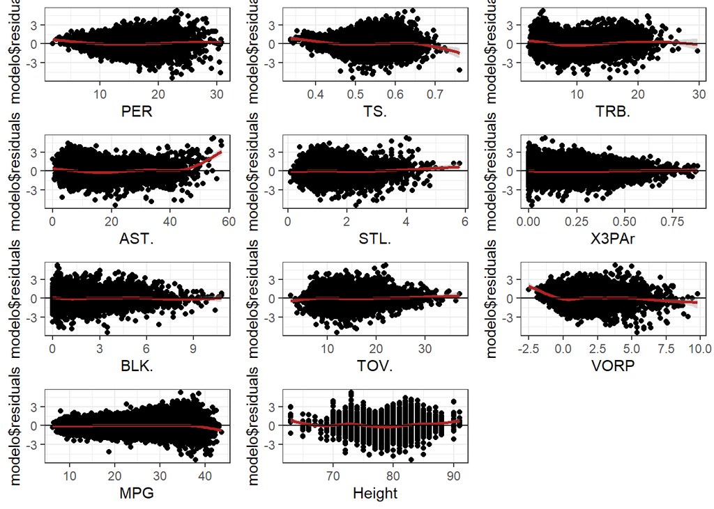

```r
library(gridExtra)

plot1 <- ggplot(data = nba_model, aes(PER, modelo$residuals)) +
    geom_point() + geom_smooth(color = "firebrick") + geom_hline(yintercept = 0) +
    theme_bw()

plot2 <- ggplot(data = nba_model, aes(TS., modelo$residuals)) +
    geom_point() + geom_smooth(color = "firebrick") + geom_hline(yintercept = 0) +
    theme_bw()

plot3 <- ggplot(data = nba_model, aes(TRB., modelo$residuals)) +
    geom_point() + geom_smooth(color = "firebrick") + geom_hline(yintercept = 0) +
    theme_bw()

plot4 <- ggplot(data = nba_model, aes(AST., modelo$residuals)) +
    geom_point() + geom_smooth(color = "firebrick") + geom_hline(yintercept = 0) +
    theme_bw()

plot5 <- ggplot(data = nba_model, aes(STL., modelo$residuals)) +
    geom_point() + geom_smooth(color = "firebrick") + geom_hline(yintercept = 0) +
    theme_bw()

plot6 <- ggplot(data = nba_model, aes(X3PAr, modelo$residuals)) +
    geom_point() + geom_smooth(color = "firebrick") + geom_hline(yintercept = 0) +
    theme_bw()

plot7 <- ggplot(data = nba_model, aes(BLK., modelo$residuals)) +
    geom_point() + geom_smooth(color = "firebrick") + geom_hline(yintercept = 0) +
    theme_bw()

plot8 <- ggplot(data = nba_model, aes(TOV., modelo$residuals)) +
    geom_point() + geom_smooth(color = "firebrick") + geom_hline(yintercept = 0) +
    theme_bw()

plot9 <- ggplot(data = nba_model, aes(VORP, modelo$residuals)) +
    geom_point() + geom_smooth(color = "firebrick") + geom_hline(yintercept = 0) +
    theme_bw()

plot10 <- ggplot(data = nba_model, aes(MPG, modelo$residuals)) +
    geom_point() + geom_smooth(color = "firebrick") + geom_hline(yintercept = 0) +
    theme_bw()

plot11 <- ggplot(data = nba_model, aes(Height, modelo$residuals)) +
    geom_point() + geom_smooth(color = "firebrick") + geom_hline(yintercept = 0) +
    theme_bw()

grid.arrange(plot1, plot2, plot3, plot4, plot5, plot6, plot7, plot8, plot9, plot10, plot11)
```

The error term has mean 0 (red line)

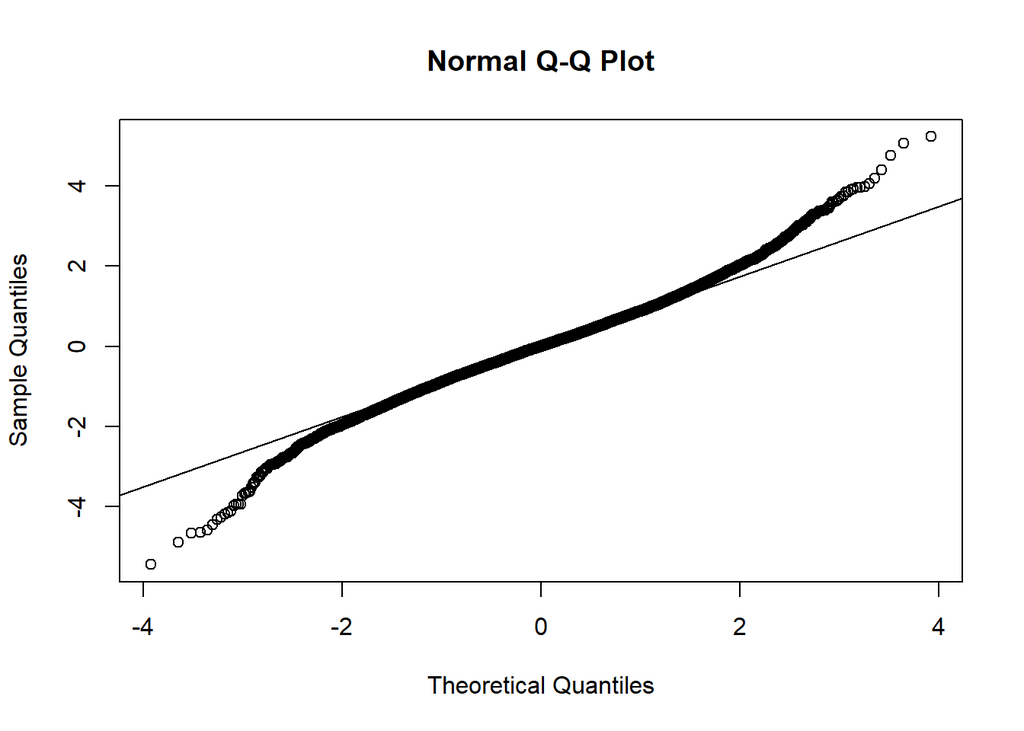

```r
qqnorm(modelo$residuals)
qqline(modelo$residuals)
```

We then proceed to analyse the model fitted values with the residuals.

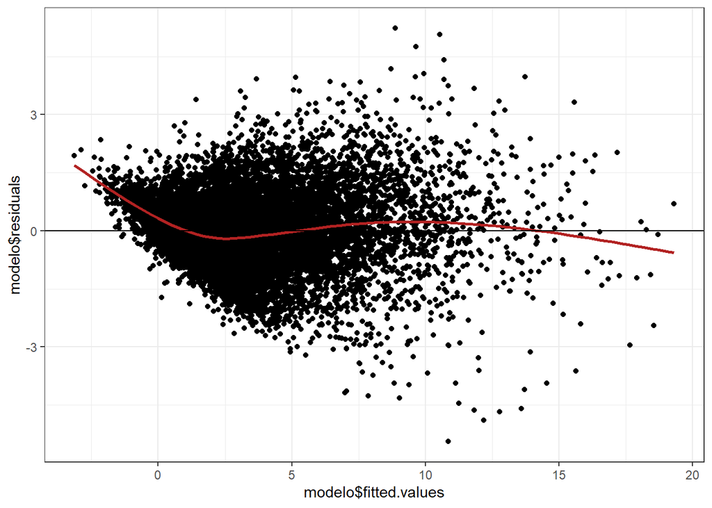

```r
ggplot(data = nba_model, aes(modelo$fitted.values, modelo$residuals)) +
geom_point() +
geom_smooth(color = "firebrick", se = FALSE) +
geom_hline(yintercept = 0) +
theme_bw()
```

The mean is close to 0, although it does deviate slightly when the fitted values are negative, suggesting we can lose some predicting capabilities, if the WS is negative. This theoretically should not be a problem, as we expected LeBron James and Michael Jordan to have large positive WS values.

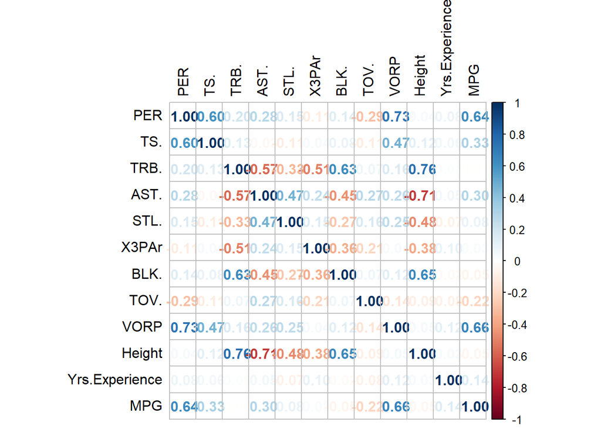

```r
library(corrplot)
corrplot(cor(dplyr::select(nba_model, PER, TS., TRB., AST., STL., X3PAr, BLK., TOV., VORP, Height, Yrs.Experience, MPG)),
         method = "number", tl.col = "black")
```

We then also check whether there is multicollinearity present in our model.

```r
library(car)
vif(modelo)
```

```
##       PER       TS.      TRB.      AST.      STL.     X3PAr      BLK.      TOV.
## 20.526751  5.192572  6.143220  7.451805  2.037644  1.661660  2.562709  3.093385
##      VORP    Height       MPG     Shot.
##  3.383922  3.928251  2.278970  5.184464
```

We observe that PER than a Variance Inflation Factor (VIF) of 20, suggesting there is multicollinearity present.

Given that PER has a very large VIF, we expect to be able to predict PER with the rest of the variables in the model, therefore we test the hypothesis.

```r
modelo_per = lm(formula = PER ~ ., data = nba_model)
summary(modelo_per)
```

```
##
## Call:
## lm(formula = PER ~ ., data = nba_model)
##
## Residuals:
##     Min      1Q  Median      3Q     Max
## -3.7723 -0.5420 -0.0479  0.4941  5.4268
##
## Coefficients:
##                  Estimate Std. Error t value Pr(>|t|)
## (Intercept)    -1.194e+01  3.591e-01 -33.243  < 2e-16 ***
## TS.             3.274e+01  2.143e-01 152.765  < 2e-16 ***
## TRB.            3.243e-01  3.384e-03  95.842  < 2e-16 ***
## AST.            1.769e-01  1.641e-03 107.804  < 2e-16 ***
## STL.            8.929e-01  1.532e-02  58.292  < 2e-16 ***
## X3PAr          -1.475e+00  5.775e-02 -25.547  < 2e-16 ***
## BLK.            4.643e-01  7.430e-03  62.491  < 2e-16 ***
## TOV.           -1.960e-01  2.842e-03 -68.963  < 2e-16 ***
## VORP           -2.085e-02  1.590e-02  -1.311  0.18978
## Shot.           3.692e-01  2.434e-03 151.698  < 2e-16 ***
## Height         -3.771e-02  4.721e-03  -7.988 1.50e-15 ***
## Weight         -1.423e-03  5.353e-04  -2.659  0.00785 **
## Yrs.Experience  1.118e-02  2.162e-03   5.171 2.37e-07 ***
## WS              2.149e-01  7.820e-03  27.478  < 2e-16 ***
## MPG             1.472e-02  1.412e-03  10.425  < 2e-16 ***
## ---
## Signif. codes:  0 '***' 0.001 '**' 0.01 '*' 0.05 '.' 0.1 ' ' 1
##
## Residual standard error: 0.8383 on 11484 degrees of freedom
## Multiple R-squared:  0.9545, Adjusted R-squared:  0.9544
## F-statistic: 1.719e+04 on 14 and 11484 DF,  p-value: < 2.2e-16
```

With the rest of the variables, we are able to predict 95% of PER, therefore it is not necessary to include it in the model.

New linear model without PER.

```r
modelo_bueno <- (lm(formula = WS ~ TS.+TRB.+AST.+STL.+X3PAr+BLK.+TOV.+VORP+Height+MPG, data = nba_model))
summary(modelo_bueno)
```

```
##
## Call:
## lm(formula = WS ~ TS. + TRB. + AST. + STL. + X3PAr + BLK. + TOV. +
##     VORP + Height + MPG, data = nba_model)
##
## Residuals:
##     Min      1Q  Median      3Q     Max
## -5.5464 -0.6203 -0.0221  0.5895  5.2025
##
## Coefficients:
##              Estimate Std. Error t value Pr(>|t|)
## (Intercept)  2.186551   0.421023   5.193 2.10e-07 ***
## TS.         11.056236   0.233916  47.266  < 2e-16 ***
## TRB.         0.020088   0.003838   5.234 1.69e-07 ***
## AST.         0.012424   0.001859   6.685 2.42e-11 ***
## STL.        -0.460743   0.017621 -26.147  < 2e-16 ***
## X3PAr       -2.087186   0.064582 -32.319  < 2e-16 ***
## BLK.        -0.051749   0.008820  -5.867 4.56e-09 ***
## TOV.        -0.088031   0.002840 -30.992  < 2e-16 ***
## VORP         1.622517   0.011443 141.796  < 2e-16 ***
## Height      -0.060846   0.004964 -12.258  < 2e-16 ***
## MPG          0.035763   0.001604  22.294  < 2e-16 ***
## ---
## Signif. codes:  0 '***' 0.001 '**' 0.01 '*' 0.05 '.' 0.1 ' ' 1
##
## Residual standard error: 1.001 on 11488 degrees of freedom
## Multiple R-squared:  0.8918, Adjusted R-squared:  0.8917
## F-statistic:  9469 on 10 and 11488 DF,  p-value: < 2.2e-16
```

Confidence interval for the new model.

```r
confint(lm(formula = WS ~ TS.+TRB.+AST.+STL.+X3PAr+BLK.+TOV.+VORP+Height+MPG, data = nba_model))
```

```
##                    2.5 %      97.5 %
## (Intercept)  1.361274787  3.01182776
## TS.         10.597721837 11.51475087
## TRB.         0.012564414  0.02761084
## AST.         0.008781052  0.01606732
## STL.        -0.495283013 -0.42620288
## X3PAr       -2.213776683 -1.96059463
## BLK.        -0.069038287 -0.03445907
## TOV.        -0.093599113 -0.08246355
## VORP         1.600087806  1.64494692
## Height      -0.070576680 -0.05111615
## MPG          0.032618150  0.03890689
```

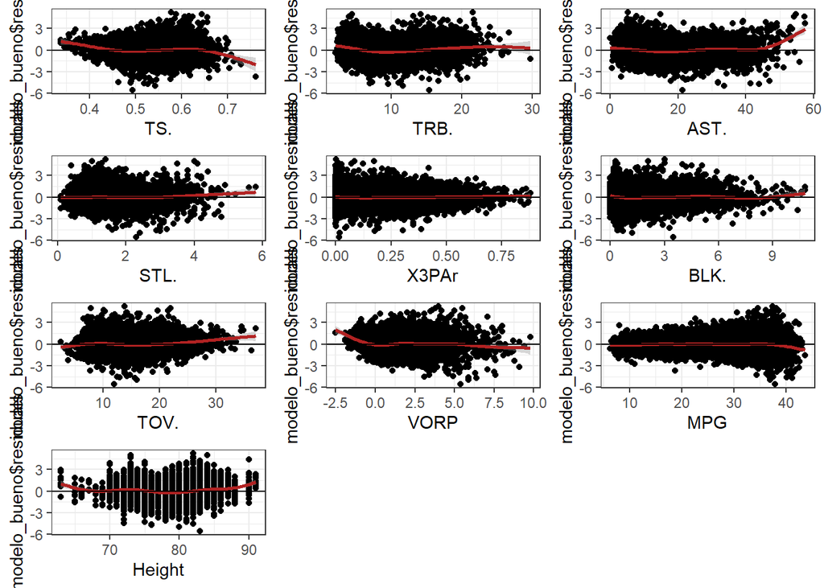

```r
library(gridExtra)

plot2 <- ggplot(data = nba_model, aes(TS., modelo_bueno$residuals)) +
    geom_point() + geom_smooth(color = "firebrick") + geom_hline(yintercept = 0) +
    theme_bw()

plot3 <- ggplot(data = nba_model, aes(TRB., modelo_bueno$residuals)) +
    geom_point() + geom_smooth(color = "firebrick") + geom_hline(yintercept = 0) +
    theme_bw()

plot4 <- ggplot(data = nba_model, aes(AST., modelo_bueno$residuals)) +
    geom_point() + geom_smooth(color = "firebrick") + geom_hline(yintercept = 0) +
    theme_bw()

plot5 <- ggplot(data = nba_model, aes(STL., modelo_bueno$residuals)) +
    geom_point() + geom_smooth(color = "firebrick") + geom_hline(yintercept = 0) +
    theme_bw()

plot6 <- ggplot(data = nba_model, aes(X3PAr, modelo_bueno$residuals)) +
    geom_point() + geom_smooth(color = "firebrick") + geom_hline(yintercept = 0) +
    theme_bw()

plot7 <- ggplot(data = nba_model, aes(BLK., modelo_bueno$residuals)) +
    geom_point() + geom_smooth(color = "firebrick") + geom_hline(yintercept = 0) +
    theme_bw()

plot8 <- ggplot(data = nba_model, aes(TOV., modelo_bueno$residuals)) +
    geom_point() + geom_smooth(color = "firebrick") + geom_hline(yintercept = 0) +
    theme_bw()

plot9 <- ggplot(data = nba_model, aes(VORP, modelo_bueno$residuals)) +
    geom_point() + geom_smooth(color = "firebrick") + geom_hline(yintercept = 0) +
    theme_bw()

plot10 <- ggplot(data = nba_model, aes(MPG, modelo_bueno$residuals)) +
    geom_point() + geom_smooth(color = "firebrick") + geom_hline(yintercept = 0) +
    theme_bw()

plot11 <- ggplot(data = nba_model, aes(Height, modelo_bueno$residuals)) +
    geom_point() + geom_smooth(color = "firebrick") + geom_hline(yintercept = 0) +
    theme_bw()

grid.arrange(plot2, plot3, plot4, plot5, plot6, plot7, plot8, plot9, plot10, plot11)
```

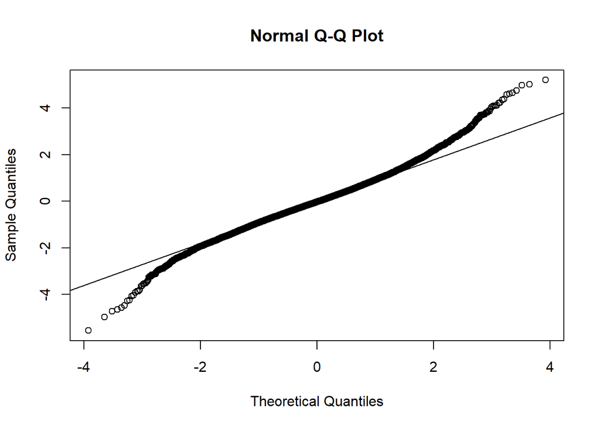

```r
qqnorm(modelo_bueno$residuals)
qqline(modelo_bueno$residuals)
```

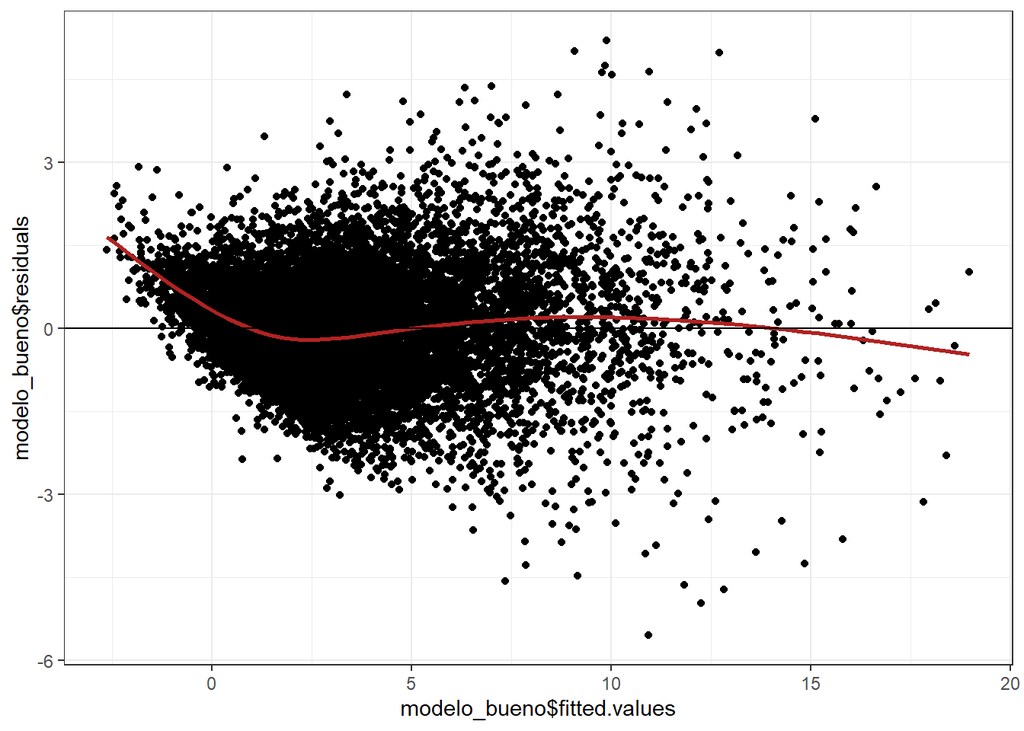

```r
ggplot(data = nba_model, aes(modelo_bueno$fitted.values, modelo_bueno$residuals)) +
geom_point() +
geom_smooth(color = "firebrick", se = FALSE) +
geom_hline(yintercept = 0) +
theme_bw()
```

But, the model still does not do well when predicting negative WS values.

We check to see if we still have some multicollinearity present.

```r
library(car)
vif(modelo_bueno)
```

```
##      TS.     TRB.     AST.     STL.    X3PAr     BLK.     TOV.     VORP
## 1.438720 3.338915 3.403966 1.652404 1.467080 1.958135 1.542573 3.085238
##   Height      MPG
## 3.830219 2.113980
```

All VIF values are low, suggesting no multicollinearity present.

We proceed to check whether there is any autocorrelation present, the closer the D-W Stat is to 2, the less autocorrelation there is.

```r
library(car)
dwt(modelo_bueno, alternative = "two.sided")
```

```
##  lag Autocorrelation D-W Statistic p-value
##    1       0.1586602      1.682156       0
##  Alternative hypothesis: rho != 0
```

Studentized residual plot.

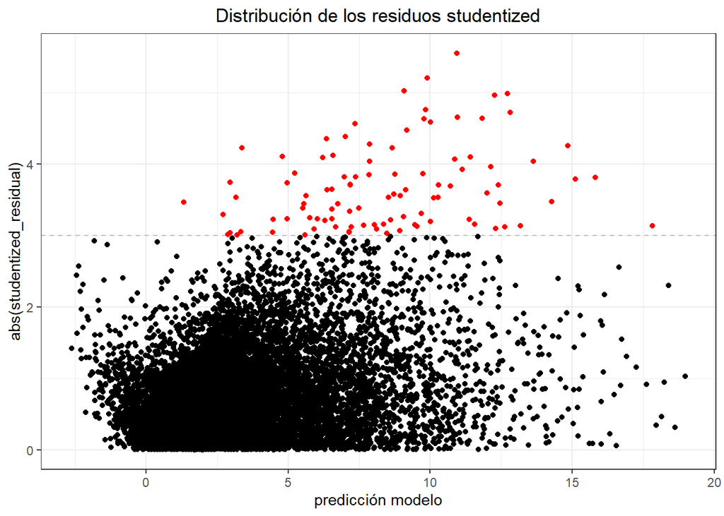

```r
library(dplyr)
nba_model$studentized_residual <- rstudent(modelo_bueno)
ggplot(data = nba_model, aes(x = predict(modelo_bueno), y = abs(studentized_residual))) +
geom_hline(yintercept = 3, color = "grey", linetype = "dashed") +
# se identifican en rojo observaciones con residuos estandarizados absolutos > 3
geom_point(aes(color = ifelse(abs(studentized_residual) > 3, 'red', 'black'))) +
scale_color_identity() +
labs(title = "Distribución de los residuos studentized",
     x = "predicción modelo") +
theme_bw() + theme(plot.title = element_text(hjust = 0.5))
```

We can observe that we have some outliers in the prediction of the model, but these are a very small amount relative to the data set.

```r
which(abs(nba_model$studentized_residual) > 3)
```

```
##  [1]    13    18   263   278   508   513   783   802  1090  1315  1570  1578
## [13]  1588  1674  1840  1865  1935  2105  2114  2365  2404  2656  2663  2667
## [25]  2960  3860  3869  3881  4256  4483  4496  4853  4855  5186  5200  5481
## [37]  5482  5484  5485  5486  5488  5492  5494  5499  5501  5502  5506  5513
## [49]  5514  5516  5521  5526  5539  5544  5552  5611  5834  5844  6107  6120
## [61]  6151  6178  6190  6805  6880  7170  7178  7238  7507  7516  7550  7563
## [73]  7592  7881  7895  8014  8244  8254  8583  8586  8621  8699  8932  8933
## [85]  8956  9277  9284  9299  9378  9638  9642  9653 10374 10446 11125 11126
## [97] 11154 11179 11477
```

# Comparison between LeBron James and Michael Jordan

We calculate which is LeBron’s best statistical year.

```r
Lebron_stats = nba %>%
  filter(Player == "LeBron James") %>%
  select(Year, TS., TRB., AST., STL., X3PAr, BLK., TOV., VORP, Height, MPG) %>%
  mutate(Suma_stats = rowSums(.[setdiff(names(.),"Year")])) %>%
  arrange(desc(Suma_stats))

Lebron_stats
```

```
##    Year   TS. TRB. AST. STL. X3PAr BLK. TOV. VORP Height      MPG Suma_stats
## 1  2010 0.604 11.1 41.8  2.2 0.253  2.0 12.3 10.4     80 39.02632   199.6833
## 2  2009 0.591 11.9 38.0  2.4 0.238  2.4 11.0 11.0     80 37.70370   195.2327
## 3  2008 0.568 11.1 37.3  2.4 0.219  2.1 11.4  9.4     80 40.36000   194.8470
## 4  2013 0.640 13.1 36.4  2.4 0.188  1.9 12.4  9.2     80 37.85526   194.0833
## 5  2011 0.594 11.4 34.9  2.1 0.188  1.3 13.8  7.9     80 38.77215   190.9542
## 6  2012 0.605 12.6 33.6  2.6 0.127  1.7 13.3  8.8     80 37.51613   190.8481
## 7  2015 0.577  9.6 38.6  2.3 0.265  1.6 15.3  5.9     80 36.13043   190.2724
## 8  2005 0.554 10.2 32.9  2.8 0.183  1.1 11.8  8.3     80 42.35000   190.1870
## 9  2006 0.568  9.8 32.8  2.0 0.208  1.5 10.7  9.0     80 42.54430   189.1203
## 10 2014 0.649 11.5 32.0  2.2 0.226  0.8 14.4  7.6     80 37.68831   187.0633
## 11 2007 0.552  9.6 29.1  2.1 0.191  1.3 11.5  7.1     80 40.89744   182.3404
## 12 2004 0.488  7.6 27.8  2.2 0.145  1.3 13.9  3.1     80 39.51899   176.0520
```

Result = 2010

```r
Lebron_2010 = Lebron_stats %>%
  filter(Year == 2010)

Lebron_2010
```

```
##   Year   TS. TRB. AST. STL. X3PAr BLK. TOV. VORP Height      MPG Suma_stats
## 1 2010 0.604 11.1 41.8  2.2 0.253    2 12.3 10.4     80 39.02632   199.6833
```

Calculate Jordan’s best statistical year

```r
Michael_stats = nba %>%
  filter(Player == "Michael Jordan") %>%
  select(Year, TS., TRB., AST., STL., X3PAr, BLK., TOV., VORP, Height, MPG) %>%
  mutate(Suma_stats = rowSums(.[setdiff(names(.),"Year")])) %>%
  arrange(desc(Suma_stats))

Michael_stats
```

```
##    Year   TS. TRB. AST. STL. X3PAr BLK. TOV. VORP Height      MPG Suma_stats
## 1  1989 0.614 11.6 34.7  3.6 0.055  1.2 11.9 11.2     78 40.18519   193.0542
## 2  1990 0.606 10.4 28.6  3.5 0.125  1.1  9.8  9.5     78 38.98780   180.6188
## 3  1988 0.603  7.8 27.0  3.9 0.027  2.4  9.6 10.9     78 40.37805   180.6080
## 4  1985 0.592  9.8 25.3  3.0 0.032  1.3 13.0  7.6     78 38.34146   176.9655
## 5  1993 0.564  9.8 25.2  3.7 0.115  1.3  8.4  8.3     78 39.32051   174.6995
## 6  1992 0.579  9.5 25.7  3.0 0.055  1.5  8.8  7.8     78 38.77500   173.7090
## 7  1991 0.605  9.5 25.2  3.7 0.051  1.7  8.7  9.1     78 37.00000   173.5560
## 8  1987 0.562  7.4 22.2  3.6 0.029  2.3  9.1  8.1     78 40.01220   171.3032
## 9  2002 0.468  9.4 30.8  2.2 0.040  0.9  9.9  2.3     78 34.88333   168.8913
## 10 1996 0.582 10.2 21.2  3.1 0.141  1.0  8.4  7.8     78 37.68293   168.1059
## 11 1995 0.493 10.3 24.2  2.3 0.079  1.5  7.0  0.8     78 39.29412   163.9661
## 12 1997 0.567  8.8 21.2  2.4 0.157  1.1  7.2  6.4     78 37.87805   163.7020
## 13 2003 0.491  9.7 21.1  2.2 0.036  1.0  9.4  2.2     78 36.96341   161.0904
## 14 1998 0.533  8.5 18.0  2.4 0.067  1.0  7.7  4.9     78 38.79268   159.8927
## 15 1986 0.533  8.0 21.7  3.9 0.055  2.7 10.5  0.7     78 25.05556   151.1436
```

Result = 1989

```r
Michael_1989 = Michael_stats %>%
  filter(Year == 1989)

Michael_1989
```

```
##   Year   TS. TRB. AST. STL. X3PAr BLK. TOV. VORP Height      MPG Suma_stats
## 1 1989 0.614 11.6 34.7  3.6 0.055  1.2 11.9 11.2     78 40.18519   193.0542
```

We have chosen to analyze what player was the best in their prime, therefore we only choose a singular year. Later on we will take into account their whole careers.

We continue to predict LeBron’s WS with his 2010 stats

```r
predict(modelo_bueno, newdata = Lebron_2010)
```

```
##        1
## 20.28099
```

According to our model, LeBron would have a WS contribution of 20.28.

Predicting Jordan’s WS.

```r
predict(modelo_bueno, newdata = Michael_1989)
```

```
##        1
## 21.61937
```

# Comparing their best year stats

```r
df_compare = merge(x = Lebron_2010, y = Michael_1989, all = TRUE)

df_compare$Year <- if_else(df_compare$Year == 2010, "Lebron", "Jordan")

df_compare = rename(df_compare, c("Player" = "Year"))

head(df_compare)
```

```
##   Player   TS. TRB. AST. STL. X3PAr BLK. TOV. VORP Height      MPG Suma_stats
## 1 Jordan 0.614 11.6 34.7  3.6 0.055  1.2 11.9 11.2     78 40.18519   193.0542
## 2 Lebron 0.604 11.1 41.8  2.2 0.253  2.0 12.3 10.4     80 39.02632   199.6833
```

Visual comparison of their stats.

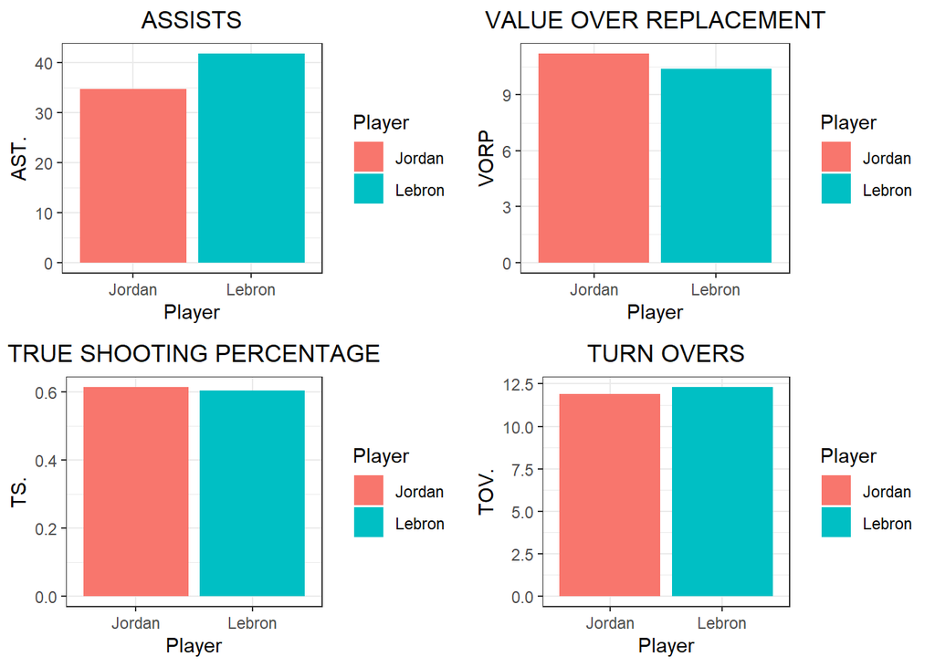

```r
library(ggpubr)


p1 <- ggplot( data = df_compare, aes(Player, AST., fill=Player) ) +
      geom_bar(stat = "identity", position = position_dodge()) +
      labs(title = "ASSISTS")+
      theme_bw() + theme(plot.title = element_text(hjust = 0.5))


p2 <- ggplot( data = df_compare, aes(Player, VORP, fill=Player) ) +
      geom_bar(stat = "identity", position = position_dodge()) +
      labs(title = "VALUE OVER REPLACEMENT")+
      theme_bw() + theme(plot.title = element_text(hjust = 0.5))

p3 <- ggplot( data = df_compare, aes(Player, TS., fill=Player) ) +
      geom_bar(stat = "identity", position = position_dodge()) +
      labs(title = "TRUE SHOOTING PERCENTAGE")+
      theme_bw() + theme(plot.title = element_text(hjust = 0.5))

p4 <- ggplot( data = df_compare, aes(Player, TOV., fill=Player) ) +
      geom_bar(stat = "identity", position = position_dodge()) +
      labs(title = "TURN OVERS")+
      theme_bw() + theme(plot.title = element_text(hjust = 0.5))

p5 <- ggplot( data = df_compare, aes(Player, Height, fill=Player) ) +
      geom_bar(stat = "identity", position = position_dodge()) +
      labs(title = "HEIGHT")+
      theme_bw() + theme(plot.title = element_text(hjust = 0.5))

p6 <- ggplot( data = df_compare, aes(Player, TRB., fill=Player) ) +
      geom_bar(stat = "identity", position = position_dodge()) +
      labs(title = "TOTAL REBOUND PERCENTAGE")+
      theme_bw() + theme(plot.title = element_text(hjust = 0.5))

p7 <- ggplot( data = df_compare, aes(Player, STL., fill=Player) ) +
      geom_bar(stat = "identity", position = position_dodge()) +
      labs(title = "STEALS")+
      theme_bw() + theme(plot.title = element_text(hjust = 0.5))

p8 <- ggplot( data = df_compare, aes(Player, X3PAr, fill=Player) ) +
      geom_bar(stat = "identity", position = position_dodge()) +
      labs(title = "3 POINT ATTEMPT RATE")+
      theme_bw() + theme(plot.title = element_text(hjust = 0.5))

p9 <- ggplot( data = df_compare, aes(Player, BLK., fill=Player) ) +
      geom_bar(stat = "identity", position = position_dodge()) +
      labs(title = "BLOCKS")+
      theme_bw() + theme(plot.title = element_text(hjust = 0.5))

p10 <- ggplot( data = df_compare, aes(Player, MPG, fill=Player) ) +
      geom_bar(stat = "identity", position = position_dodge()) +
      labs(title = "MINUTES PER GAME")+
      theme_bw() + theme(plot.title = element_text(hjust = 0.5))


final_plot1 <- ggarrange(p1, p2, p3, p4)
final_plot2 <- ggarrange(p5, p6, p7, p8)
final_plot3 <- ggarrange(p9, p10)

final_plot1
```

Both players have very similar stats, although LeBron does provide a higher percentage of the teams total assists, when compared to Jordan. LeBron has always been a very complete player, being able to score, assist and rebound effectively, while Jordan has scored more and defended better. Therefore it is not strange to see that LeBron provides a higher percentage of assists.

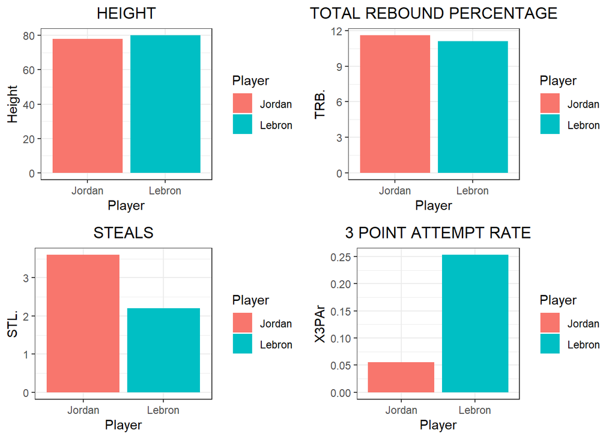

```r
final_plot2
```

It is also very interesting to see the 3 point attempt rate difference. In the past decade, the NBA has evolved greatly, before teams looked to score two-pointers and generally did not shoot the 3 that much, while nowadays, most teams look for 3 pointers. This explains the difference in the 3 point attempt rate.

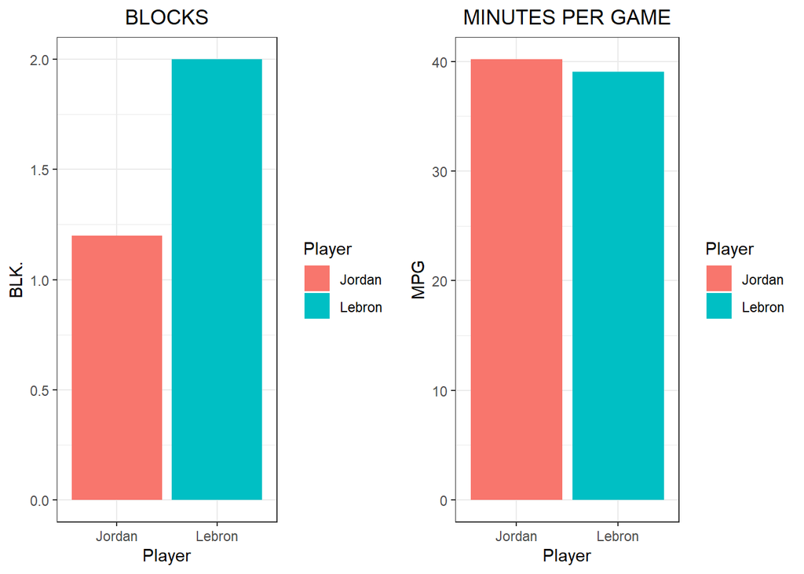

```r
final_plot3
```

LeBron also does average more blocks, mainly due to his large frame and size.

# Career Comparison

We will now look at both players entire careers.

We select Jordan’s stats.

```r
Michael_stats_AVG = nba %>%
  filter(Player == "Michael Jordan") %>%
  select(Year, TS., TRB., AST., STL., X3PAr, BLK., TOV., VORP, Height, MPG) %>%
  colMeans()

Michael_stats_AVG_df <- as.data.frame(Michael_stats_AVG)

Michael_stats_AVG_df <- data.frame(t(Michael_stats_AVG_df))
```

And now LeBron’s.

```r
Lebron_stats_AVG = nba %>%
  filter(Player == "LeBron James") %>%
  select(Year, TS., TRB., AST., STL., X3PAr, BLK., TOV., VORP, Height, MPG) %>%
  colMeans()

Lebron_stats_AVG_df <- as.data.frame(Lebron_stats_AVG)

Lebron_stats_AVG_df <- data.frame(t(Lebron_stats_AVG_df))
```

Statistical comparison between their whole careers.

```r
df_compare_AVG = merge(x = Lebron_stats_AVG_df, y = Michael_stats_AVG_df, all = TRUE)

df_compare_AVG$Year <- if_else(df_compare_AVG$Year == 2009.5, "Lebron", "Jordan")

df_compare_AVG = rename(df_compare_AVG, c("Player" = "Year"))

head(df_compare_AVG)
```

```
##   Player       TS.     TRB.     AST.     STL.      X3PAr     BLK.      TOV.
## 1 Jordan 0.5594667  9.38000 24.80667 3.100000 0.07093333 1.466667  9.293333
## 2 Lebron 0.5825000 10.79167 34.60000 2.308333 0.20258333 1.583333 12.650000
##       VORP Height      MPG
## 1 6.506667     78 37.57002
## 2 8.141667     80 39.19692
```

We will now try to predict who has been more constant during their whole career.

Predicting LeBron’s career WS.

```r
predict(modelo_bueno, newdata = Lebron_stats_AVG_df)
```

```
## Lebron_stats_AVG
##         16.33562
```

Career WS = 16.3

Predicting Jordan’s career WS.

```r
predict(modelo_bueno, newdata = Michael_stats_AVG_df)
```

```
## Michael_stats_AVG
##          13.55317
```

MJ Career WS = 13.5

While Jordan contributed more towards his WS than LeBron James, during their whole career, LeBron has managed to maintain WS stat.

# Career Statistical Analysis

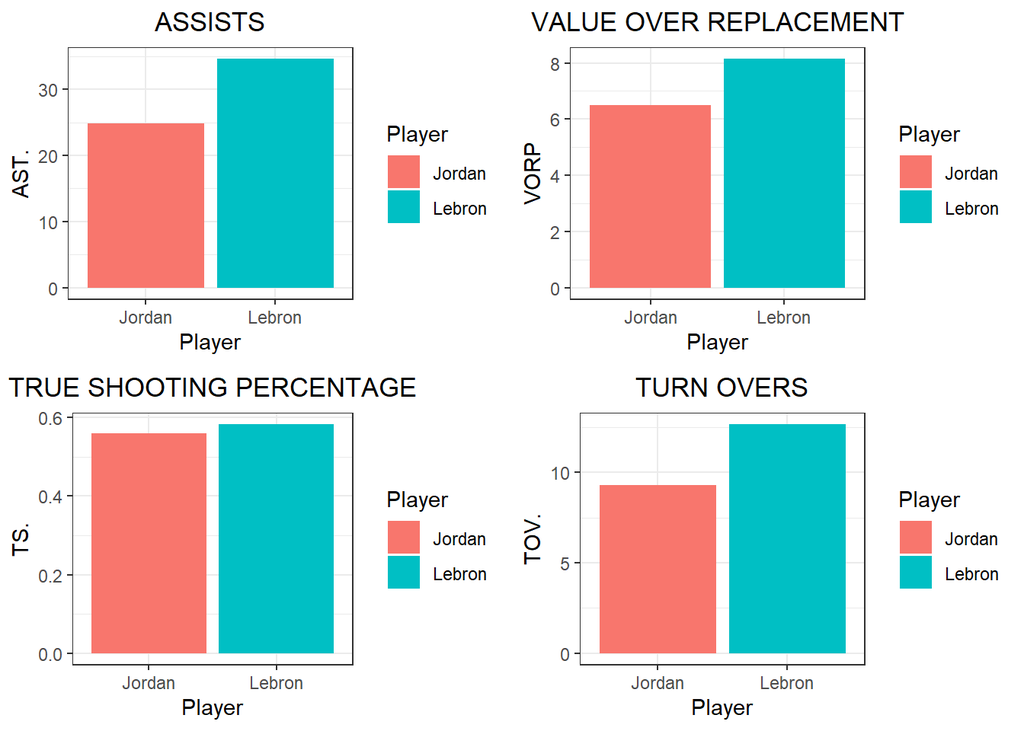

```r
library(ggpubr)


p11 <- ggplot( data = df_compare_AVG, aes(Player, AST., fill=Player) ) +
      geom_bar(stat = "identity", position = position_dodge()) +
      labs(title = "ASSISTS")+
      theme_bw() + theme(plot.title = element_text(hjust = 0.5))


p12 <- ggplot( data = df_compare_AVG, aes(Player, VORP, fill=Player) ) +
      geom_bar(stat = "identity", position = position_dodge()) +
      labs(title = "VALUE OVER REPLACEMENT")+
      theme_bw() + theme(plot.title = element_text(hjust = 0.5))

p13 <- ggplot( data = df_compare_AVG, aes(Player, TS., fill=Player) ) +
      geom_bar(stat = "identity", position = position_dodge()) +
      labs(title = "TRUE SHOOTING PERCENTAGE")+
      theme_bw() + theme(plot.title = element_text(hjust = 0.5))

p14 <- ggplot( data = df_compare_AVG, aes(Player, TOV., fill=Player) ) +
      geom_bar(stat = "identity", position = position_dodge()) +
      labs(title = "TURN OVERS")+
      theme_bw() + theme(plot.title = element_text(hjust = 0.5))

p15 <- ggplot( data = df_compare_AVG, aes(Player, Height, fill=Player) ) +
      geom_bar(stat = "identity", position = position_dodge()) +
      labs(title = "HEIGHT")+
      theme_bw() + theme(plot.title = element_text(hjust = 0.5))

p16 <- ggplot( data = df_compare_AVG, aes(Player, TRB., fill=Player) ) +
      geom_bar(stat = "identity", position = position_dodge()) +
      labs(title = "TOTAL REBOUND PERCENTAGE")+
      theme_bw() + theme(plot.title = element_text(hjust = 0.5))

p17 <- ggplot( data = df_compare_AVG, aes(Player, STL., fill=Player) ) +
      geom_bar(stat = "identity", position = position_dodge()) +
      labs(title = "STEALS")+
      theme_bw() + theme(plot.title = element_text(hjust = 0.5))

p18 <- ggplot( data = df_compare_AVG, aes(Player, X3PAr, fill=Player) ) +
      geom_bar(stat = "identity", position = position_dodge()) +
      labs(title = "3 POINT ATTEMPT RATE")+
      theme_bw() + theme(plot.title = element_text(hjust = 0.5))

p19 <- ggplot( data = df_compare_AVG, aes(Player, BLK., fill=Player) ) +
      geom_bar(stat = "identity", position = position_dodge()) +
      labs(title = "BLOCKS")+
      theme_bw() + theme(plot.title = element_text(hjust = 0.5))

p20 <- ggplot( data = df_compare_AVG, aes(Player, MPG, fill=Player) ) +
      geom_bar(stat = "identity", position = position_dodge()) +
      labs(title = "MINUTES PER GAME")+
      theme_bw() + theme(plot.title = element_text(hjust = 0.5))


final_plot4 <- ggarrange(p11, p12, p13, p14)
final_plot5 <- ggarrange(p15, p16, p17, p18)
final_plot6 <- ggarrange(p19, p20)

final_plot4
```

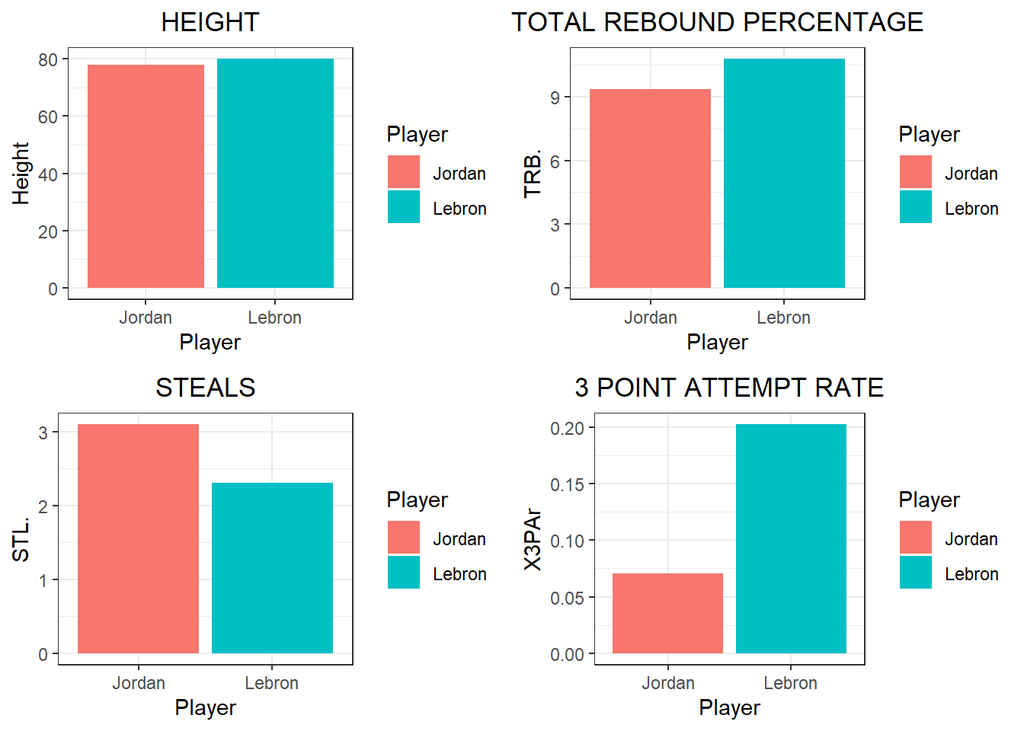

```r
final_plot5
```

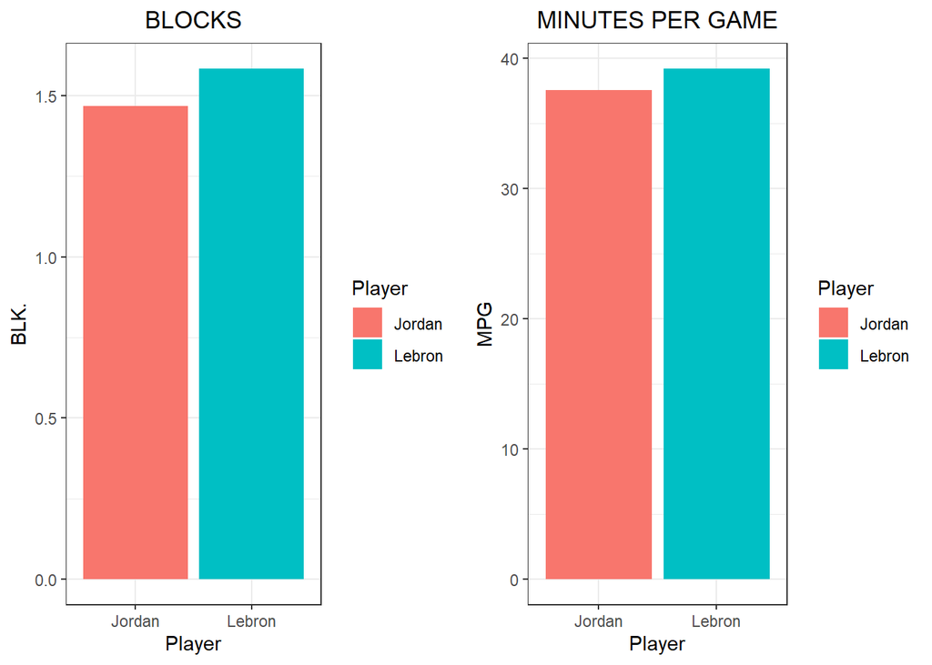

```r
final_plot6
```

The main difference between their career stats is the 3 point attempt rate (mainly due to the evolution of the NBA).

# Final Conclusion

This report has aimed to finish the NBA GOAT debate by providing a statistically rigorous conclusion.

Maybe the question we are trying to answer is not the correct one. We should try to ask a more specific question. If we were to choose one player to play for one season in our team, then we would chose Michael Jordan. Nevertheless, if we were to choose a player to play in our team for their whole career, a better option would be LeBron James.